[figure not shown]

Analyse des ventes & du comportement clients  
Data-driven insights for decision making

# 🎯 Objectif du projet — Lapage 📚

Ce notebook a pour objectif d’**analyser les ventes et le comportement des clients de l’entreprise Lapage**, une librairie ayant développé son activité de vente en ligne, afin d’en extraire des **insights clairs et exploitables pour le comité de direction (CODIR)**.

L’analyse vise à fournir une **vision synthétique et stratégique de la performance commerciale**, ainsi qu’une meilleure compréhension des profils et habitudes des clients.

## 🧩 Contexte

Initialement positionnée comme une **librairie physique**, l’entreprise **Lapage** a lancé son site de vente en ligne il y a deux ans afin de répondre à la demande croissante de ses clients et d’élargir son activité.

Dans ce contexte, la direction souhaite aujourd’hui :

- mieux **suivre l’évolution de l’activité e-commerce** ;
- comprendre les **dynamiques de vente** ;
- analyser le **comportement des clients en ligne**.

Pour mener cette étude, trois jeux de données sont mis à disposition :

- un fichier **clients** (genre, année de naissance) ;
- un fichier **produits** (prix et catégories) ;
- un fichier **transactions** (dates d’achat, clients et produits).

## 📈 Objectifs principaux

Le travail se structure autour de **deux axes complémentaires**.

### Axe 1 — Analyse de l’activité commerciale

- Étudier l’**évolution du chiffre d’affaires dans le temps** ;
- Mettre en évidence les tendances à l’aide de **moyennes mobiles** ;
- Analyser le **nombre de clients**, de **transactions** et de **produits vendus** ;
- Identifier les **produits les plus performants (tops)** et les **moins performants (flops)** ;
- Étudier la **répartition des ventes par catégorie**.

### Axe 2 — Analyse du comportement client

- Étudier la **répartition du chiffre d’affaires par client** ;
- Analyser la **dispersion des ventes** à l’aide d’une **courbe de Lorenz** ;
- Mettre en évidence des **corrélations entre les variables clients** :
  - âge ;
  - genre ;
  - fréquence d’achat ;
  - panier moyen ;
  - catégories de livres achetées.
- Appliquer et justifier l’utilisation de **tests statistiques adaptés** :
  - test du **χ² (khi-deux)** ;
  - **ANOVA** ou **test de Student** ;
  - **corrélation de Pearson ou de Spearman**.
- Identifier et traiter les **clients atypiques (BtoB)** afin de garantir la pertinence des analyses.

## 🧠 Finalité

Les résultats issus de cette étude permettront :

- d’**accompagner la prise de décision stratégique du CODIR** ;
- d’orienter les **choix marketing et commerciaux** (offres, ciblage, positionnement) ;
- de proposer une **lecture claire, pédagogique et exploitable des données**, adaptée à un public non technique.

> 💡 *Cette analyse a été menée dans une démarche de rigueur, de clarté et de reproductibilité, afin de fournir à Lapage une vision fiable et structurée de son activité e-commerce et du comportement de ses clients.*

## 📘 Sommaire

- 📂 Étape 1 — Importation et préparation des données
  - 1.1 Importation des librairies
  - 1.2 Chargement des fichiers CSV
- 🔎 Étape 2 — Analyse exploratoire des données (EDA)
  - 2.1 Analyse du fichier clients
  - 2.2 Analyse du fichier produits
  - 2.3 Analyse du fichier transactions
  - 2.3.1 Analyse des doublons dans le fichier transactions
  - 2.3.2 Traitements des doublons dans le fichier transactions
- 🔗 Étape 3 — Construction du jeu de données d’analyse
  - 3.1 Jointure transactions + produits
  - 3.2 Jointure avec les données clients
  - 3.3 Validation du dataset final
- 📈 Étape 4 — Analyse temporelle des ventes
  - 4.1 Évolution du chiffre d’affaires
  - 4.2 Moyennes mobiles
  - 4.3 Clients, transactions, produits par période
- 🏆 Étape 5 — Analyse de la performance des produits
  - 5.1 Tops produits
  - 5.2 Flops produits
  - 5.3 Répartition du CA par catégorie
- 🧑‍🤝‍🧑 Étape 6 — Analyse des clients
  - 6.1 Profils clients & données démographiques
  - 6.2 Concentration du CA & courbe de Lorenz
- ⚠️ Étape 7 — Clients atypiques (BtoB)
  - 7.1 Identification des clients atypiques
  - 7.2 Justification de l’exclusion pour l’analyse statistique
  - 7.3 Nouveau dataset “sans BtoB”
- 🧪 Étape 8 — Corrélations & tests statistiques
  - 8.1 Corrélations exploratoires
  - 8.2.1 — χ² (catégories)
  - 8.2.2 — Vérification des hypothèses (Smirnov/KS, QQ-plot, histogramme, Levene)
  - 8.2.3 — ANOVA (panier moyen selon tranche d’âge)
  - 8.2.4 — Pearson & Spearman (âge vs comportements d’achat)
  - 8.3 Interprétation des résultats
- Conclusion et recommandations

## Étape 1 — Importation et préparation des données

### 1.1 - Importation des librairies

```python
#Importation de la librairie Pandas
from IPython.display import display, HTML
import pandas as pd
import numpy as np
import matplotlib.pyplot as plt
import plotly.express as px
import seaborn as sns
import warnings
warnings.filterwarnings("ignore", category=UserWarning, module="openpyxl")

print("✅ Tout est installé et prêt 🎉")
```

```
✅ Tout est installé et prêt 🎉
```

```python
# Affichage de toutes les colonnes du dataframe
pd.set_option('display.max_columns', None)
```

**Réponse :**  
pd.set_option( 'display.max_columns', None)

✅ Toutes les colonnes du DataFrame seront désormais affichées.

### 1.2 - Chargements des fichiers

```python
#Importation du fichier customers.csv
customers = pd.read_csv(
    "Data/customers.csv",
    sep=";",
    dtype={"client_id": "string", "sex": "string", "birth": "Int64"},
    low_memory=False
)

#Importation du fichier products.csv
products = pd.read_csv(
    "Data/products.csv",
    sep=";",
    dtype={"id_prod": "string", "price": "float64", "categ": "Int64"},
    low_memory=False
)

#Importation du fichier transactions.csv
transactions = pd.read_csv(
    "Data/transactions.csv",
    sep=";",
    dtype={"id_prod": "string", "session_id": "string", "client_id": "string"},
    parse_dates=["date"],
    low_memory=False
)
```

**Résultat :** 🔥 Importation terminée :  
les fichiers **customers.csv**, **products.csv** et **transactions.csv** sont chargés avec succès !

## Etape 2 - Analyse exploratoire des fichiers

### 2.1 - Analyse exploratoire du fichier customer.csv

```python
#Afficher les dimensions du dataset
rows, cols = customers.shape
display(HTML(f"""
<p style='font-family: Segoe UI, Arial; font-size:18px; color:#e0e0e0;'>
Le tableau comporte <span style='color:#ffcc00; font-weight:bold;'>{rows:,}</span> observation(s) ou article(s)<br>
Le tableau comporte <span style='color:#ffcc00; font-weight:bold;'>{cols}</span> colonne(s)
</p>
"""))
```

Le tableau comporte 8,621 observation(s) ou article(s)  
Le tableau comporte 3 colonne(s)

```python
# Focus sur un client (approche qualitative)
customers.sample(1)
```

|  | client_id | sex | birth |
| --- | --- | --- | --- |
| 5069 | c_3519 | m | 1974 |

```python
# Types de variables & valeurs manquantes
customers.info()
customers.isnull().sum()
```

```
<class 'pandas.core.frame.DataFrame'>
RangeIndex: 8621 entries, 0 to 8620
Data columns (total 3 columns):
 #   Column     Non-Null Count  Dtype
---  ------     --------------  -----
 0   client_id  8621 non-null   string
 1   sex        8621 non-null   string
 2   birth      8621 non-null   Int64
dtypes: Int64(1), string(2)
memory usage: 210.6 KB
```

```
client_id    0
sex          0
birth        0
dtype: int64
```

```python
# ✅ Vérification d'unicité & doublons sur l'identifiant client
is_unique = customers["client_id"].is_unique
dup_count = customers.duplicated(subset=["client_id"]).sum()

display(HTML(f"""
<p style="font-family: Segoe UI, Arial; font-size:18px; color:#e0e0e0;">
• Unicité de <b style="color:#ffcc00;">client_id</b> :
<b style="color:{'#34d399' if is_unique else '#f87171'};">{is_unique}</b><br>
• Nombre de doublons sur <b style="color:#ffcc00;">client_id</b> :
<b style="color:{'#34d399' if dup_count==0 else '#f87171'};">{dup_count}</b>
</p>
"""))
```

• Unicité de **client_id** : **True**  
• Nombre de doublons sur **client_id** : **0**

```python
# Analyse des variables catégorielles (sex)
sex_counts = customers['sex'].value_counts()
sex_percent = customers['sex'].value_counts(normalize=True) * 100

df_sex = pd.DataFrame({
    "Effectif": sex_counts,
    "Pourcentage (%)": sex_percent.round(2)
})

df_sex
```

| sex | Effectif | Pourcentage (%) |
| --- | --- | --- |
| f | 4490 | 52.08 |
| m | 4131 | 47.92 |

```python
# Analyse descriptive de l’âge
ANNEE_ANALYSE = 2026

customers['age'] = ANNEE_ANALYSE - customers['birth']
customers[['birth', 'age']].head()
```

|  | birth | age |
| --- | --- | --- |
| 0 | 1967 | 59 |
| 1 | 1975 | 51 |
| 2 | 1984 | 42 |
| 3 | 1962 | 64 |
| 4 | 1943 | 83 |

```python
# Vérifier les valeurs possibles de sex (qualité)
customers["sex"].value_counts(dropna=False)
```

```
sex
f    4490
m    4131
Name: count, dtype: Int64
```

```python
f_pct = df_sex.loc["f", "Pourcentage (%)"]
m_pct = df_sex.loc["m", "Pourcentage (%)"]

display(HTML(f"""
<p style="font-family: Segoe UI, Arial; font-size:18px; color:#e0e0e0;">
Répartition : <b style="color:#ffcc00;">Femmes</b> = <b>{f_pct}%</b> •
<b style="color:#ffcc00;">Hommes</b> = <b>{m_pct}%</b>
</p>
"""))
```

Répartition : **Femmes** = **52.08%** • **Hommes** = **47.92%**

```python
import plotly.express as px

fig = px.histogram(customers, x="age", nbins=100, title="Distribution de l'âge des clients")
fig.update_layout(template="plotly_dark")
fig.show()
```

[output not shown]

👥 **Synthèse — Analyse exploratoire du fichier customers.csv**

📌 **Dimensions :** 8 621 lignes • 3 colonnes (client_id, sex, birth)

🧬 **Types :** client_id (string), sex (string), birth (int)

✅ **Valeurs manquantes :** 0 (aucune valeur null détectée)

🔎 **Qualité / Identifiants :**  
• Unicité de client_id : True  
• Doublons sur client_id : 0

🚻 **Répartition de la variable sex :**  
• Femmes : 52.08%  
• Hommes : 47.92%  
(modalités observées : f, m)

✅ **Conclusion :** le fichier **customers.csv** est **cohérent** (pas de valeurs manquantes, pas de doublons sur l’identifiant) et peut être utilisé pour les jointures ultérieures avec la table **transactions**.

### 2.2 - Analyse exploratoire du fichier Products.csv

```python
#Afficher les dimensions du dataset
rows, cols = products.shape
display(HTML(f"""
<p style='font-family: Segoe UI, Arial; font-size:18px; color:#e0e0e0;'>
Le tableau comporte <span style='color:#ffcc00; font-weight:bold;'>{rows:,}</span> observation(s) ou article(s)<br>
Le tableau comporte <span style='color:#ffcc00; font-weight:bold;'>{cols}</span> colonne(s)
</p>
"""))
```

Le tableau comporte 3,286 observation(s) ou article(s)  
Le tableau comporte 3 colonne(s)

```python
# Dimensions & structure
rows, cols = products.shape
products.info()
products.isnull().sum()
```

```
<class 'pandas.core.frame.DataFrame'>
RangeIndex: 3286 entries, 0 to 3285
Data columns (total 3 columns):
 #   Column   Non-Null Count  Dtype
---  ------   --------------  -----
 0   id_prod  3286 non-null   string
 1   price    3286 non-null   float64
 2   categ    3286 non-null   Int64
dtypes: Int64(1), float64(1), string(1)
memory usage: 80.4 KB
```

```
id_prod    0
price      0
categ      0
dtype: int64
```

✅ **Valeurs manquantes**

Aucune valeur manquante n’a été détectée dans le fichier **Products**.  
Le dataset est **complet** et directement exploitable pour les analyses suivantes.

```python
# Unicité & doublons
is_unique_prod = products["id_prod"].is_unique
dup_prod = products.duplicated(subset=["id_prod"]).sum()

is_unique_prod, dup_prod = products["id_prod"].is_unique, products.duplicated(subset=["id_prod"]).sum()

print(f"Unicité de id_prod : {is_unique_prod}")
print(f"Nombre de doublons sur id_prod : {dup_prod}")

if dup_prod == 0:
    print("✅ Aucun doublon détecté.")
else:
    print("⚠️ Doublons détectés : à investiguer avant les jointures.")
```

```
Unicité de id_prod : True
Nombre de doublons sur id_prod : 0
✅ Aucun doublon détecté.
```

📦 **Vérification de l’unicité des produits**

- Unicité de **id_prod** : **True**
- Nombre de doublons sur **id_prod** : **0**

✅ Aucun doublon détecté.

```python
# Analyse des prix
products['price'].describe()
```

```
count    3286.000000
mean       21.863597
std        29.849786
min         0.620000
25%         6.990000
50%        13.075000
75%        22.990000
max       300.000000
Name: price, dtype: float64
```

```python
# Analyse des prix (tableau)
categ_counts = products["categ"].value_counts()
categ_pct = (products["categ"].value_counts(normalize=True) * 100).round(2)

df_categ = pd.DataFrame({
    "Effectif": categ_counts,
    "Pourcentage (%)": categ_pct
})
df_categ
```

| categ | Effectif | Pourcentage (%) |
| --- | --- | --- |
| 0 | 2308 | 70.24 |
| 1 | 739 | 22.49 |
| 2 | 239 | 7.27 |

🏷️ **Lecture de la répartition des catégories (categ)**

• **Catégorie 0** : 70.24% (2308 produits) produits → catégorie majoritaire.

• **Catégorie 1** : 22.49% (739 produits) produits → proportion intermédiaire.

• **Catégorie 2** : 7.27% (239 produits) produits → minoritaire.

✅ **Interprétation :** la variable **categ** est **déséquilibrée** (catégorie 0 dominante).  
👉 Pour les analyses suivantes, il faudra garder en tête que la catégorie 2 contient peu d’observations (résultats potentiellement plus sensibles / moins stables).

```python
# Graphique Analyse des prix
fig = px.box(products, y="price", title="Distribution des prix des produits")
fig.update_layout(template="plotly_dark")
fig.show()
```

[output not shown]

- La majorité des produits se situe dans une zone de prix relativement basse (boîte proche de 0–30€).
- La distribution est **asymétrique à droite** : quelques produits ont des prix beaucoup plus élevés que la moyenne.
- Les points au-dessus de la moustache représentent des **valeurs atypiques** (produits “premium” ou cas spécifiques).

✅ Ces valeurs élevées ne sont pas supprimées à ce stade : elles peuvent être cohérentes métier (gamme premium).

```python
# 🔎 Lecture analytique – justification chiffrée
# Objectif :
# Appuyer l'interprétation métier sur des indicateurs statistiques concrets
# afin de relier clairement les résultats numériques aux conclusions formulées.

# Statistiques globales sur les prix
products["price"].describe()
```

```
count    3286.000000
mean       21.863597
std        29.849786
min         0.620000
25%         6.990000
50%        13.075000
75%        22.990000
max       300.000000
Name: price, dtype: float64
```

```python
# 🔎 Lecture analytique par catégorie
# Objectif :
# Vérifier la cohérence entre les catégories produits (categ)
# et les niveaux de prix observés.
products.groupby("categ")["price"].describe()
```

| categ | count | mean | std | min | 25% | 50% | 75% | max |
| --- | --- | --- | --- | --- | --- | --- | --- | --- |
| 0 | 2308.0 | 11.732795 | 7.565755 | 0.62 | 5.5875 | 10.32 | 16.655 | 40.99 |
| 1 | 739.0 | 25.531421 | 15.425162 | 2.00 | 13.3900 | 22.99 | 33.990 | 80.99 |
| 2 | 239.0 | 108.354686 | 49.561431 | 30.99 | 71.0650 | 101.99 | 136.530 | 300.00 |

🧾 **Lecture du tableau describe() par catégorie**

- **count** : nombre de produits dans la catégorie.
- **mean** : prix **moyen** des produits de la catégorie.
- **std** : **écart-type** (dispersion des prix). Plus il est élevé, plus les prix sont variés.
- **min** / **max** : prix minimum / maximum observés.
- **25%** / **50%** / **75%** : quartiles (valeurs seuils : 25%, médiane, 75% des prix).

💡 Exemple : si **50%** = 10.32, alors la moitié des produits de la catégorie ont un prix ≤ 10.32.

📊 **Lecture analytique des catégories**

- **Catégorie 0** : majorité des produits (~70%), prix faibles et homogènes → entrée de gamme.
- **Catégorie 1** : gamme intermédiaire, prix moyens plus élevés.
- **Catégorie 2** : produits premium, prix élevés et forte dispersion.

👉 Les différences de prix observées sont cohérentes avec une segmentation par gamme.

```python
# Focus produit (qualitatif)
products.sample(1)
```

|  | id_prod | price | categ |
| --- | --- | --- | --- |
| 2813 | 0_667 | 12.99 | 0 |

🔍 **Focus produit (qualitatif)**  
• Objectif : contrôler visuellement un exemple de produit (id_prod, price, categ).  
• Vérifications : **prix plausible**, **catégorie attendue**, et absence d’anomalie évidente.

📦 **Synthèse — Analyse exploratoire du fichier Products.csv**

📌 **Dimensions :** 3 286 lignes • 3 colonnes (id_prod, price, categ)

🧬 **Types :** id_prod (string), price (float), categ (int)

✅ **Valeurs manquantes :** 0 (aucune valeur null détectée)

🔎 **Qualité / Identifiants :**  
• Unicité de id_prod : True  
• Doublons sur id_prod : 0

💰 **Analyse de la variable price :**  
• Prix minimum : 0.62  
• Médiane (50%) : 13.08  
• 25% des produits ≤ 6.99 • 75% des produits ≤ 22.99  
• Prix maximum : 300.00  
(distribution asymétrique : présence de produits “premium” / outliers)

🏷️ **Répartition de la variable categ :**  
• Catégorie 0 : 70.24% (2 308 produits)  
• Catégorie 1 : 22.49% (739 produits)  
• Catégorie 2 : 7.27% (239 produits)

✅ **Conclusion :** le fichier **Products.csv** est **cohérent** (pas de valeurs manquantes, pas de doublons sur l’identifiant) et peut être utilisé pour les jointures ultérieures avec la table **transactions**.

### 2.3 - Analyse exploratoire du fichier Transactions.csv

```python
#Afficher les dimensions du dataset
rows, cols = transactions.shape
display(HTML(f"""
<p style='font-family: Segoe UI, Arial; font-size:18px; color:#e0e0e0;'>
Le tableau comporte <span style='color:#ffcc00; font-weight:bold;'>{rows:,}</span> observation(s) ou articles<br>
Le tableau comporte <span style='color:#ffcc00; font-weight:bold;'>{cols}</span> colonnes
</p>
"""))
```

Le tableau comporte 1,048,575 observation(s) ou articles  
Le tableau comporte 4 colonnes

```python
# 👤 Exemple client (aléatoire) — affichage de toutes les colonnes
# Objectif : voir concrètement les lignes d’un client, ses sessions et ses produits.
pd.set_option("display.max_columns", None)

tx = transactions.copy()
client_ex = tx["client_id"].dropna().sample(1, random_state=42).iloc[0]

print("Client exemple :", client_ex)
tx[tx["client_id"] == client_ex].sort_values(["session_id", "date"]).head(20)
```

```
Client exemple : c_6048
```

|  | id_prod | date | session_id | client_id |
| --- | --- | --- | --- | --- |
| 219266 | 0_1412 | 2021-10-24 13:47:19.093730 | s_109467 | c_6048 |
| 219283 | 0_1000 | 2021-10-24 14:28:26.546015 | s_109467 | c_6048 |
| 233958 | 0_1356 | 2021-11-09 14:26:54.645834 | s_117095 | c_6048 |
| 233971 | 0_1631 | 2021-11-09 15:00:35.310148 | s_117095 | c_6048 |
| 283825 | 0_1480 | 2021-12-29 11:52:52.126284 | s_141819 | c_6048 |
| 283829 | 0_1863 | 2021-12-29 11:55:32.925418 | s_141819 | c_6048 |
| 283830 | 0_1994 | 2021-12-29 11:55:54.015871 | s_141819 | c_6048 |
| 28804 | 0_1356 | 2021-04-01 05:04:24.640111 | s_14306 | c_6048 |
| 28805 | 0_1377 | 2021-04-01 05:06:02.937276 | s_14306 | c_6048 |
| 28820 | 0_1569 | 2021-04-01 05:29:46.489762 | s_14306 | c_6048 |
| 28828 | 0_1352 | 2021-04-01 05:38:55.947324 | s_14306 | c_6048 |
| 353896 | 0_1356 | 2022-03-09 14:26:54.645834 | s_176696 | c_6048 |
| 353909 | 0_1631 | 2022-03-09 15:00:35.310148 | s_176696 | c_6048 |
| 363634 | 0_1483 | 2022-03-20 07:11:46.182803 | s_181733 | c_6048 |
| 363648 | 0_1401 | 2022-03-20 07:43:23.790670 | s_181733 | c_6048 |
| 363650 | 0_1362 | 2022-03-20 07:45:49.449418 | s_181733 | c_6048 |
| 363656 | 0_1344 | 2022-03-20 07:52:31.478036 | s_181733 | c_6048 |
| 364160 | 1_505 | 2022-03-20 20:50:13.531844 | s_181992 | c_6048 |
| 367109 | 0_1468 | 2022-03-23 17:22:15.197602 | s_183413 | c_6048 |
| 367116 | 0_2104 | 2022-03-23 17:37:51.339385 | s_183413 | c_6048 |

```python
# Sessions du client + volume de lignes par session
client_rows = tx[tx["client_id"] == client_ex].copy()

client_rows["session_id"].value_counts().head(15)
```

```
session_id
s_8878      4
s_14306     4
s_30892     4
s_337919    4
s_204665    4
s_344263    4
s_314760    4
s_181733    4
s_94361     3
s_141819    3
s_272488    3
s_215815    3
s_186290    3
s_183413    3
s_109467    2
Name: count, dtype: Int64
```

```python
# Détail d'une session du client
# On prend la session la plus active
session_ex = client_rows["session_id"].value_counts().idxmax()
print("Session exemple :", session_ex)

client_rows[client_rows["session_id"] == session_ex] \
    .sort_values("date") \
    .reset_index(drop=True)
```

```
Session exemple : s_8878
```

|  | id_prod | date | session_id | client_id |
| --- | --- | --- | --- | --- |
| 0 | 0_1483 | 2021-03-20 07:11:46.182803 | s_8878 | c_6048 |
| 1 | 0_1401 | 2021-03-20 07:43:23.790670 | s_8878 | c_6048 |
| 2 | 0_1362 | 2021-03-20 07:45:49.449418 | s_8878 | c_6048 |
| 3 | 0_1344 | 2021-03-20 07:52:31.478036 | s_8878 | c_6048 |

```python
# Produits les plus ajoutés dans cette session (répétitions = quantité)
client_rows[client_rows["session_id"] == session_ex]["id_prod"] \
    .value_counts() \
    .head(20)
```

```
id_prod
0_1483    1
0_1401    1
0_1362    1
0_1344    1
Name: count, dtype: Int64
```

🧠 **Interprétation métier — répétitions dans une même session**

- ✅ **Ce n’est pas forcément une anomalie** : un client peut ajouter un article, puis le ré-ajouter plus tard (augmentation de quantité, retours en arrière, navigation…).
- ⚠️ Donc, une “duplication” sur la clé **(session_id, id_prod)** peut refléter un **comportement d’achat normal**, pas un doublon “technique”.

👉 **Conséquence pour l’analyse :** au lieu de supprimer ces répétitions, on va les traiter comme une **quantité implicite** (nombre de lignes) et chercher plutôt des **valeurs vraiment aberrantes** (ex : session avec un volume anormalement élevé d’ajouts).

```python
# Volume de lignes par session-client (proxy d’activité / quantité)
session_client_counts = (
    transactions.groupby(["client_id", "session_id"])
    .size()
    .rename("nb_lignes")
    .reset_index()
)

session_client_counts["nb_lignes"].describe()
```

```
count    345505.000000
mean          1.989939
std           1.276025
min           1.000000
25%           1.000000
50%           2.000000
75%           3.000000
max          14.000000
Name: nb_lignes, dtype: float64
```

```python
session_client_counts.sort_values("nb_lignes", ascending=False).head(20)
```

|  | client_id | session_id | nb_lignes |
| --- | --- | --- | --- |
| 226547 | c_5995 | s_118668 | 14 |
| 205326 | c_5523 | s_96857 | 13 |
| 205292 | c_5523 | s_215292 | 13 |
| 326917 | c_8303 | s_342045 | 13 |
| 326854 | c_8303 | s_179575 | 13 |
| 326868 | c_8303 | s_21005 | 13 |
| 308210 | c_7855 | s_168560 | 12 |
| 308238 | c_7855 | s_256347 | 12 |
| 319722 | c_8127 | s_93892 | 12 |
| 319721 | c_8127 | s_286482 | 12 |
| 319719 | c_8127 | s_182934 | 12 |
| 308229 | c_7855 | s_226986 | 12 |
| 258571 | c_6714 | s_240291 | 11 |
| 273214 | c_7027 | s_3533 | 11 |
| 275772 | c_7088 | s_159413 | 11 |
| 156906 | c_4445 | s_316001 | 11 |
| 102176 | c_3212 | s_36768 | 11 |
| 156908 | c_4445 | s_65873 | 11 |
| 226454 | c_5993 | s_218040 | 11 |
| 326196 | c_8286 | s_86536 | 11 |

```python
q1 = session_client_counts["nb_lignes"].quantile(0.25)
q3 = session_client_counts["nb_lignes"].quantile(0.75)
iqr = q3 - q1
seuil = q3 + 1.5 * iqr

seuil, session_client_counts[session_client_counts["nb_lignes"] > seuil].shape[0]
```

```
(np.float64(6.0), 2873)
```

```python
# Structure & valeurs manquantes
# Dimensions & structure
rows, cols = transactions.shape
transactions.info()
transactions.isnull().sum()
```

```
<class 'pandas.core.frame.DataFrame'>
RangeIndex: 1048575 entries, 0 to 1048574
Data columns (total 4 columns):
 #   Column      Non-Null Count   Dtype
---  ------      --------------   -----
 0   id_prod     687534 non-null  string
 1   date        687534 non-null  datetime64[ns]
 2   session_id  687534 non-null  string
 3   client_id   687534 non-null  string
dtypes: datetime64[ns](1), string(3)
memory usage: 32.0 MB
```

```
id_prod       361041
date          361041
session_id    361041
client_id     361041
dtype: int64
```

**🧩 Lecture – Valeurs manquantes (transactions)**

- Le dataset contient **1,048,575** lignes.
- On observe **361,041** valeurs manquantes par colonne (même ordre de grandeur sur chaque champ).

👉 Cela suggère l’existence d’un bloc de lignes incomplètes (ex : événements non exploitables / logs partiels). Ces lignes seront traitées dans la section **nettoyage** (suppression ou filtrage selon la règle métier).

```python
# Vérification des identifiants isolés

# Unicité des sessions
transactions["session_id"].is_unique

# Unicité des clients (normalement False)
transactions["client_id"].is_unique

# Unicité des produits (normalement False)
transactions["id_prod"].is_unique

print(f"session_id unique ?  {transactions['session_id'].is_unique}")
print(f"client_id unique ?   {transactions['client_id'].is_unique}")
print(f"id_prod unique ?     {transactions['id_prod'].is_unique}")
```

```
session_id unique ?  False
client_id unique ?   False
id_prod unique ?     False
```

**🔑 Interprétation – Unicité des identifiants**

- **client_id** n’est pas unique : normal, un client peut effectuer plusieurs achats.
- **session_id** n’est pas unique : normal, une session peut contenir plusieurs lignes (plusieurs produits / ajouts).
- **id_prod** n’est pas unique : normal, un même produit peut être acheté par plusieurs clients.

👉 Conclusion : aucune colonne seule ne joue le rôle de **clé primaire**. L’analyse des doublons doit donc se faire avec une clé composée (ex : `client_id + session_id + id_prod`) et/ou une logique métier.

```python
# Nombre de transactions par client
transactions["client_id"].value_counts().describe()

# Nombre de produits par session
transactions["session_id"].value_counts().describe()
```

```
count    345505.0
mean     1.989939
std      1.276025
min           1.0
25%           1.0
50%           2.0
75%           3.0
max          14.0
Name: count, dtype: Float64
```

```python
# Nombre d'occurrences par client / session / produit
tx_repeat = (
    transactions
    .groupby(["client_id", "session_id", "id_prod"])
    .size()
    .reset_index(name="nb_occurrences")
)

tx_repeat.describe()
```

|  | nb_occurrences |
| --- | --- |
| count | 686679.000000 |
| mean | 1.001245 |
| std | 0.035347 |
| min | 1.000000 |
| 25% | 1.000000 |
| 50% | 1.000000 |
| 75% | 1.000000 |
| max | 3.000000 |

**📈 Lecture – Volume de lignes par client et par session**

👉 Interprétation : une **session** correspond à une séquence d’actions (ajouts panier), et peut contenir **plusieurs lignes** (plusieurs produits ou répétitions), ce qui est attendu sur une table d’événements.

```python
# Metrics sur les répétitions (client_id, session_id, id_prod)
total_triplets = tx_repeat.shape[0]
nb_repetitions = (tx_repeat["nb_occurrences"] > 1).sum()
part_repetitions = (nb_repetitions / total_triplets) * 100
max_observe = int(tx_repeat["nb_occurrences"].max())

# (Valeurs visibles en output texte)
print("Triplets analysés :", f"{total_triplets:,}".replace(",", " "))
print("Répétitions (nb_occurrences > 1) :", f"{nb_repetitions:,}".replace(",", " "))
print("Part des répétitions :", f"{part_repetitions:.2f}%")
print("Maximum observé :", max_observe)
```

```
Triplets analysés : 686 679
Répétitions (nb_occurrences > 1) : 853
Part des répétitions : 0.12%
Maximum observé : 3
```

**🧾 Lecture – Répétitions d’un même produit dans une session**

| Indicateur | Valeur |
| --- | --- |
| Triplets analysés | 686 679 |
| Répétitions (nb_occurrences > 1) | 853 |
| Part des répétitions | 0.12% |
| Maximum observé | 3 |

- On regroupe par **(client_id, session_id, id_prod)** pour mesurer le nombre de répétitions d’un produit par client dans une session.

👉 Interprétation métier : ces répétitions peuvent être **légitimes** (ré-ajout au panier, ajustement de quantité, navigation). Elles ne doivent donc pas être traitées comme des “doublons techniques” par défaut, mais comme un **signal d’activité**.

```python
# Produits les plus achetés / clients qui achetent le plus de produit
# 1) Produits les plus "achetés" (proxy = nb de lignes / ajouts)
top_products = (
    transactions["id_prod"]
    .value_counts()
    .head(10)
    .reset_index()
)
top_products.columns = ["id_prod", "nb_achats"]  # nb_achats = nb de lignes

# 2) Clients qui achètent le plus (proxy = nb de lignes / ajouts)
top_clients = (
    transactions["client_id"]
    .value_counts()
    .head(10)
    .reset_index()
)
top_clients.columns = ["client_id", "nb_achats"]

print("Top produits (id_prod) par nombre de lignes :")
display(top_products)

print("Top clients (client_id) par nombre de lignes :")
display(top_clients)
```

```
Top produits (id_prod) par nombre de lignes :
```

|  | id_prod | nb_achats |
| --- | --- | --- |
| 0 | 1_369 | 2340 |
| 1 | 1_417 | 2269 |
| 2 | 1_414 | 2246 |
| 3 | 1_498 | 2202 |
| 4 | 1_425 | 2163 |
| 5 | 1_403 | 2040 |
| 6 | 1_413 | 2036 |
| 7 | 1_412 | 2014 |
| 8 | 1_406 | 2003 |
| 9 | 1_407 | 2001 |

```
Top clients (client_id) par nombre de lignes :
```

|  | client_id | nb_achats |
| --- | --- | --- |
| 0 | c_1609 | 25586 |
| 1 | c_6714 | 9199 |
| 2 | c_3454 | 6793 |
| 3 | c_4958 | 5222 |
| 4 | c_2140 | 405 |
| 5 | c_3263 | 403 |
| 6 | c_2595 | 398 |
| 7 | c_2077 | 386 |
| 8 | c_1637 | 384 |
| 9 | c_7421 | 381 |

```python
# Sécurité : on s'assure que le top est trié et en string
top_products_plot = top_products.sort_values("nb_achats", ascending=False).copy()
top_products_plot["id_prod"] = top_products_plot["id_prod"].astype(str)

fig = px.bar(
    top_products_plot,
    x="id_prod",
    y="nb_achats",
    title="Top 10 produits les plus achetés (proxy = nombre de lignes)",
    labels={"id_prod": "Produit (id_prod)", "nb_achats": "Nombre d'ajouts / lignes"}
)

fig.update_layout(
    template="plotly_dark",
    xaxis_tickangle=-35
)

fig.show()
```

[output not shown]

- Le graphique présente les **10 produits** les plus fréquents dans **Transactions.csv**.
- **Important :** en l’absence de variable *quantity*, le volume est estimé via le **nombre de lignes** (proxy d’activité / d’ajouts).
- Le produit le plus fréquent est **1_369** avec **2340** lignes, soit environ **0.22%** du dataset.

```python
# Produits les plus présents (sans compter les répétitions exactes)
top_products_unique = (
    transactions.drop_duplicates(subset=["client_id", "session_id", "id_prod"])["id_prod"]
    .value_counts()
    .head(10)
    .reset_index()
)
top_products_unique.columns = ["id_prod", "nb_sessions_clients"]

display(top_products_unique)
```

|  | id_prod | nb_sessions_clients |
| --- | --- | --- |
| 0 | 1_369 | 2333 |
| 1 | 1_417 | 2263 |
| 2 | 1_414 | 2244 |
| 3 | 1_498 | 2196 |
| 4 | 1_425 | 2161 |
| 5 | 1_403 | 2036 |
| 6 | 1_413 | 2032 |
| 7 | 1_412 | 2013 |
| 8 | 1_407 | 1999 |
| 9 | 1_396 | 1997 |

🧾 **Synthèse — Répétitions dans les transactions**

L’analyse a porté sur les répétitions d’un même produit acheté par un même client au sein d’une même session (**client_id, session_id, id_prod**).

- La grande majorité des transactions apparaissent **une seule fois**.
- Les répétitions sont **très marginales** (moins de 0,2 % des cas).
- Le maximum observé est de **3 occurrences** pour un même produit dans une session.
- Ces cas correspondent à des **comportements d’achat plausibles** (ré-ajouts, ajustement de quantité).

✅ **Conclusion :** les répétitions observées ne constituent pas des erreurs de données en soi. Elles sont donc conservées à ce stade afin de préserver l’information métier.

➡️ **Étape suivante :** une analyse dédiée sera menée sur les **doublons techniques** et les **valeurs manquantes**, afin de décider des traitements adaptés (suppression, agrégation ou conservation).

### 2.3.1 - Analyse des doublons & valeurs manquantes dans le fichier Transactions.csv

```python
cols_tx = ["id_prod", "date", "session_id", "client_id"]
rows = len(transactions)
nulls = transactions[cols_tx].isna().sum()

summary_missing = pd.DataFrame({
    "Non-null": rows - nulls,
    "Valeurs manquantes": nulls,
    "% manquantes": (nulls / rows * 100).round(2)
})

display(summary_missing)

# Lignes "exploitables" = toutes les colonnes clés présentes
tx_ok = transactions.dropna(subset=cols_tx).copy()

# Lignes "incomplètes" = au moins 1 colonne clé manquante
tx_missing = transactions[transactions[cols_tx].isna().any(axis=1)].copy()

# Cas très fréquent : lignes "totalement vides" (toutes NaN sur les 4 colonnes)
tx_all_nan = transactions[transactions[cols_tx].isna().all(axis=1)].copy()

print("Nb lignes total :", rows)
print("Nb lignes exploitables (4 champs présents) :", len(tx_ok))
print("Nb lignes incomplètes (>=1 champ manquant) :", len(tx_missing))
print("Nb lignes entièrement vides (4 champs manquants) :", len(tx_all_nan))
```

|  | Non-null | Valeurs manquantes | % manquantes |
| --- | --- | --- | --- |
| id_prod | 687534 | 361041 | 34.43 |
| date | 687534 | 361041 | 34.43 |
| session_id | 687534 | 361041 | 34.43 |
| client_id | 687534 | 361041 | 34.43 |

```
Nb lignes total : 1048575
Nb lignes exploitables (4 champs présents) : 687534
Nb lignes incomplètes (>=1 champ manquant) : 361041
Nb lignes entièrement vides (4 champs manquants) : 361041
```

```python
# Contrôle 1 — Détection des doublons techniques (Transactions exploitables)

dup_exact_ok = tx_ok.duplicated().sum()
dup_strict_ok = tx_ok.duplicated(subset=cols_tx).sum()

print("\nDoublons exacts (ligne complète) sur lignes exploitables :", dup_exact_ok)
print("Doublons stricts sur (client, session, produit, date) sur lignes exploitables :", dup_strict_ok)

if dup_exact_ok > 0:
    display(tx_ok[tx_ok.duplicated(keep=False)].sort_values(cols_tx).head(20))
```

```
Doublons exacts (ligne complète) sur lignes exploitables : 0
Doublons stricts sur (client, session, produit, date) sur lignes exploitables : 0
```

```python
# Contrôle 2 — Répétitions métier (achats multiples dans une même session)

tx_repeat = (
    tx_ok.groupby(["client_id", "session_id", "id_prod"])
         .size()
         .reset_index(name="nb_occurrences")
)

triplets = len(tx_repeat)
rep_gt1 = (tx_repeat["nb_occurrences"] > 1).sum()
part_rep = (rep_gt1 / triplets * 100) if triplets else 0
max_rep = tx_repeat["nb_occurrences"].max() if triplets else 0

print("\nTriplets analysés (client, session, produit) :", triplets)
print("Répétitions (nb_occurrences > 1) :", rep_gt1)
print("Part des répétitions : {:.2f}%".format(part_rep))
print("Maximum observé (même produit, même session) :", max_rep)

# Aperçu des cas les + élevés
display(tx_repeat.sort_values("nb_occurrences", ascending=False).head(10))
```

```
Triplets analysés (client, session, produit) : 686679
Répétitions (nb_occurrences > 1) : 853
Part des répétitions : 0.12%
Maximum observé (même produit, même session) : 3
```

|  | client_id | session_id | id_prod | nb_occurrences |
| --- | --- | --- | --- | --- |
| 480648 | c_6385 | s_43170 | 0_1440 | 3 |
| 480601 | c_6385 | s_217835 | 0_1440 | 3 |
| 123191 | c_2174 | s_145937 | 1_376 | 2 |
| 241193 | c_3542 | s_88825 | 1_351 | 2 |
| 291873 | c_4200 | s_304141 | 1_383 | 2 |
| 13394 | c_1160 | s_72275 | 0_1049 | 2 |
| 273851 | c_3972 | s_300801 | 2_102 | 2 |
| 331631 | c_4689 | s_22586 | 0_1534 | 2 |
| 44279 | c_1522 | s_70408 | 1_436 | 2 |
| 182832 | c_291 | s_170317 | 0_1399 | 2 |

```python
# Contrôle 3 — Valeurs manquantes dans Transactions (vue globale)

rows, cols = transactions.shape
nulls = transactions.isnull().sum()

summary_tx = pd.DataFrame({
    "Non-null": rows - nulls,
    "Valeurs manquantes": nulls,
    "% manquantes": (nulls/rows*100).round(2)
})
summary_tx
```

|  | Non-null | Valeurs manquantes | % manquantes |
| --- | --- | --- | --- |
| id_prod | 687534 | 361041 | 34.43 |
| date | 687534 | 361041 | 34.43 |
| session_id | 687534 | 361041 | 34.43 |
| client_id | 687534 | 361041 | 34.43 |

🧾 **Synthèse — Analyse exploratoire du fichier Transactions.csv**

📌 **Dimensions :** 1 048 575 lignes • 4 colonnes (id_prod, date, session_id, client_id)

🧬 **Types :** id_prod (string), date (datetime), session_id (string), client_id (string)

⚠️ **Valeurs manquantes :** 361 041 valeurs manquantes par colonne (soit 34.43% des lignes)

🔗 **Cohérence (clés étrangères) — hors NaN :**  
• Transactions avec id_prod absent de **Products** : 0  
• Transactions avec client_id absent de **Customers** : 0

🛒 **Achats multiples (cas métier) :**  
Analyse des répétitions d’un même produit acheté par un même client dans une même session :  
• Nombre de cas avec répétition (**nb_occurrences > 1**) : 853  
• Maximum observé : 3

✅ **Conclusion :**  
Après suppression des **lignes incomplètes** (valeurs manquantes sur les champs clés), le jeu de données **Transactions.csv** ne présente **aucun doublon technique** sur les transactions exploitables.

Les répétitions observées correspondent à des **cas métier légitimes** (achats multiples d’un même produit au sein d’une session) et sont conservées.

🔜 **Les contrôles de doublons seront réévalués après les jointures** avec les tables *Customers* et *Products*, étape à laquelle des duplications peuvent légitimement apparaître suite à l’enrichissement des données.

## Étape 3 — Construction du jeu de données d’analyse

### Étape 3.1 — Jointure transactions + products

```python
# Colonnes de Transactions (rappel)
cols_tx = ["id_prod", "date", "session_id", "client_id"]

# 1) Lignes totalement vides sur les colonnes clés (inutilisables pour toute analyse)
transactions_empty = transactions[transactions[cols_tx].isna().all(axis=1)].copy()

# 2) Lignes partiellement remplies (à étudier si besoin)
transactions_partial = transactions[
    transactions[cols_tx].isna().any(axis=1) & ~transactions[cols_tx].isna().all(axis=1)
].copy()
```

```python
# Lignes joignables avec Products : on exige uniquement la clé id_prod
transactions_joinable_products = transactions.dropna(subset=["id_prod"]).copy()

print("Total lignes Transactions :", len(transactions))
print("Transactions vides (4 NaN) :", len(transactions_empty))
print("Transactions partielles :", len(transactions_partial))
print("Transactions joignables Products (id_prod présent) :", len(transactions_joinable_products))
```

```
Total lignes Transactions : 1048575
Transactions vides (4 NaN) : 361041
Transactions partielles : 0
Transactions joignables Products (id_prod présent) : 687534
```

```python
# 1) Lignes non-joignables car id_prod manquant
tx_missing_idprod = transactions[transactions["id_prod"].isna()].copy()

print("🔎 Audit avant jointure Transactions + Products")
print("- Total lignes Transactions :", len(transactions))
print("- Lignes non-joignables (id_prod manquant) :", len(tx_missing_idprod))
print("- % non-joignables :", round(len(tx_missing_idprod) / len(transactions) * 100, 2), "%")

# 2) Vérifier si ces lignes sont "vides" sur toutes les colonnes clés (cas 4 NaN)
tx_missing_all_keys = tx_missing_idprod[tx_missing_idprod[cols_tx].isna().all(axis=1)]
print("- Parmi elles, lignes vides sur les 4 colonnes clés :", len(tx_missing_all_keys))

# 3) Montrer quelques exemples (références)
print("\n📌 Exemples de lignes non-joignables (id_prod manquant) :")
display(
    tx_missing_idprod[cols_tx]
    .head(10)
)

# 4) Exemple où date/session/client sont là mais pas id_prod
tx_missing_idprod_but_has_info = tx_missing_idprod[
    tx_missing_idprod[["date", "session_id", "client_id"]].notna().all(axis=1)
]
print("\n📌 Cas potentiellement exploitables autrement (mais sans produit) :",
      len(tx_missing_idprod_but_has_info))
if len(tx_missing_idprod_but_has_info) > 0:
    display(tx_missing_idprod_but_has_info[cols_tx].head(10))
```

```
🔎 Audit avant jointure Transactions + Products
- Total lignes Transactions : 1048575
- Lignes non-joignables (id_prod manquant) : 361041
- % non-joignables : 34.43 %
- Parmi elles, lignes vides sur les 4 colonnes clés : 361041

📌 Exemples de lignes non-joignables (id_prod manquant) :
```

|  | id_prod | date | session_id | client_id |
| --- | --- | --- | --- | --- |
| 687534 | <NA> | NaT | <NA> | <NA> |
| 687535 | <NA> | NaT | <NA> | <NA> |
| 687536 | <NA> | NaT | <NA> | <NA> |
| 687537 | <NA> | NaT | <NA> | <NA> |
| 687538 | <NA> | NaT | <NA> | <NA> |
| 687539 | <NA> | NaT | <NA> | <NA> |
| 687540 | <NA> | NaT | <NA> | <NA> |
| 687541 | <NA> | NaT | <NA> | <NA> |
| 687542 | <NA> | NaT | <NA> | <NA> |
| 687543 | <NA> | NaT | <NA> | <NA> |

```
📌 Cas potentiellement exploitables autrement (mais sans produit) : 0
```

```python
# Déduplication côté Products (clé id_prod)
products_dedup = products.drop_duplicates(subset=["id_prod"]).copy()

# Jointure Transactions + Products
transactions_products = transactions_joinable_products.merge(
    products_dedup[["id_prod", "price", "categ"]],
    on="id_prod",
    how="left",
    indicator="merge_products"
)

print("Contrôle jointure (merge_products) :")
print(transactions_products["merge_products"].value_counts())

display(transactions_products.head(3))
print("Shape transactions_products :", transactions_products.shape)
```

```
Contrôle jointure (merge_products) :
merge_products
both          687534
left_only          0
right_only         0
Name: count, dtype: int64
```

|  | id_prod | date | session_id | client_id | price | categ | merge_products |
| --- | --- | --- | --- | --- | --- | --- | --- |
| 0 | 0_1259 | 2021-03-01 00:01:07.843138 | s_1 | c_329 | 11.99 | 0 | both |
| 1 | 0_1390 | 2021-03-01 00:02:26.047414 | s_2 | c_664 | 19.37 | 0 | both |
| 2 | 0_1352 | 2021-03-01 00:02:38.311413 | s_3 | c_580 | 4.50 | 0 | both |

```
Shape transactions_products : (687534, 7)
```

```python
# NaN sur les colonnes ajoutées par Products
missing_products = transactions_products[["price", "categ"]].isna().sum()
print("\nNaN sur colonnes Products ajoutées :")
print(missing_products)

# Doublons exacts (ligne complète) après jointure
dup_exact = transactions_products.duplicated().sum()
print("\nDoublons exacts (ligne complète) :", dup_exact)

# Afficher un exemple si besoin
if dup_exact > 0:
    display(transactions_products[transactions_products.duplicated(keep=False)].head(10))
```

```
NaN sur colonnes Products ajoutées :
price    0
categ    0
dtype: int64

Doublons exacts (ligne complète) : 0
```

```python
print("Nb id_prod uniques dans Products :", products["id_prod"].nunique())
print("Nb id_prod uniques après dédup :", products_dedup["id_prod"].nunique())
```

```
Nb id_prod uniques dans Products : 3286
Nb id_prod uniques après dédup : 3286
```

🔗 **Étape 3.1 — Jointure Transactions + Products**

Objectif : enrichir chaque transaction avec les informations produit (**price**, **categ**) via une jointure sur la clé id_prod.

**📌 Préparation**  
• On conserve uniquement les transactions **joignables** à Products (id_prod présent).  
• On sécurise la jointure côté Products en gardant **une ligne par id_prod** (déduplication).

| Transactions totales | 1 048 575 |
| --- | --- |
| Transactions vides (4 NaN) | 361 041 |
| Transactions joignables à Products (id_prod présent) | 687 534 |
| Dataset après jointure (lignes, colonnes) | (687 534, 7) |

**🧪 Contrôles post-jointure**

- **Qualité de la jointure :** 100% des transactions joignables ont un match produit (merge = both uniquement).
- **Valeurs manquantes sur colonnes ajoutées :** 0 sur **price** et **categ**.
- **Doublons exacts :** 0 après jointure.

✅ **Conclusion :** la jointure **Transactions + Products** est validée : aucune perte sur les transactions joignables, aucune information produit manquante, et aucun doublon exact introduit.  
👉 Prochaine étape : joindre les **données clients** (Customers) sur **client_id**.

### Étape 3.2 — Jointure avec les données clients (customers)

```python
# Colonnes attendues côté Customers
cols_customers = ["client_id", "sex", "birth"]

# Vérification rapide
print("Colonnes Customers :", customers.columns.tolist())
```

```
Colonnes Customers : ['client_id', 'sex', 'birth', 'age']
```

```python
# Déduplication côté Customers (1 ligne par client)
customers_unique = customers.drop_duplicates(subset=["client_id"]).copy()

print("Clients totaux :", len(customers))
print("Clients uniques :", len(customers_unique))
```

```
Clients totaux : 8621
Clients uniques : 8621
```

```python
# Jointure sur client_id
transactions_full = transactions_products.merge(
    customers_unique[cols_customers],
    on="client_id",
    how="left",
    indicator="merge_customers"
)

# Contrôle de la jointure
print("Contrôle jointure Customers (merge_customers) :")
print(transactions_full["merge_customers"].value_counts())

display(transactions_full.head(3))
print("Shape transactions_full :", transactions_full.shape)
```

```
Contrôle jointure Customers (merge_customers) :
merge_customers
both          687534
left_only          0
right_only         0
Name: count, dtype: int64
```

|  | id_prod | date | session_id | client_id | price | categ | merge_products | sex | birth | merge_customers |
| --- | --- | --- | --- | --- | --- | --- | --- | --- | --- | --- |
| 0 | 0_1259 | 2021-03-01 00:01:07.843138 | s_1 | c_329 | 11.99 | 0 | both | f | 1967 | both |
| 1 | 0_1390 | 2021-03-01 00:02:26.047414 | s_2 | c_664 | 19.37 | 0 | both | m | 1960 | both |
| 2 | 0_1352 | 2021-03-01 00:02:38.311413 | s_3 | c_580 | 4.50 | 0 | both | m | 1988 | both |

```
Shape transactions_full : (687534, 10)
```

```python
# 🔍 Valeurs manquantes sur colonnes clients

missing_customers = transactions_full[["sex", "birth"]].isna().sum()

print("\nNaN sur colonnes Customers ajoutées :")
print(missing_customers)
```

```
NaN sur colonnes Customers ajoutées :
sex      0
birth    0
dtype: int64
```

```python
# 🔁 Doublons exacts après jointure

dup_exact = transactions_full.duplicated().sum()
print("\nDoublons exacts (ligne complète) :", dup_exact)

if dup_exact > 0:
    display(transactions_full[transactions_full.duplicated(keep=False)].head(10))
```

```
Doublons exacts (ligne complète) : 0
```

```python
print("- Lignes finales :", len(transactions_full))
print("- Colonnes :", transactions_full.columns.tolist())
print("- % clients sans info sexe :", round(missing_customers["sex"] / len(transactions_full) * 100, 2), "%")
print("- % clients sans info birth :", round(missing_customers["birth"] / len(transactions_full) * 100, 2), "%")
```

```
- Lignes finales : 687534
- Colonnes : ['id_prod', 'date', 'session_id', 'client_id', 'price', 'categ', 'merge_products', 'sex', 'birth', 'merge_customers']
- % clients sans info sexe : 0.0 %
- % clients sans info birth : 0.0 %
```

```python
dataset_final = transactions_full.copy()

# (optionnel) on enlève les colonnes de contrôle merge si tu ne veux pas les garder
dataset_final = dataset_final.drop(columns=["merge_products", "merge_customers"], errors="ignore")

dataset_final.shape, dataset_final.columns.tolist()[:10]
```

```
((687534, 8),
 ['id_prod',
  'date',
  'session_id',
  'client_id',
  'price',
  'categ',
  'sex',
  'birth'])
```

🧩 **Étape 3.2 — Jointure Transactions + Products + Customers**

[output not shown]

✅ **Conclusion :** Les jointures **Transactions → Products** puis **+ Customers** sont **validées** : aucune perte sur les lignes jointes (100% *both*), aucune valeur manquante sur les attributs ajoutés (**price, categ, sex, birth**) et **0 doublon technique exact** après construction. Le dataset peut maintenant être renommé en **dataset_final** et passer à l’**Étape 3.3 (validation)**.

### Étape 3.3 — Validation du dataset final

```python
print("✅ Colonnes dataset_final :", dataset_final.columns.tolist())
```

```
✅ Colonnes dataset_final : ['id_prod', 'date', 'session_id', 'client_id', 'price', 'categ', 'sex', 'birth']
```

```python
print("✅ Shape dataset_final :", dataset_final.shape)
```

```
✅ Shape dataset_final : (687534, 8)
```

```python
# Valeurs manquantes globales
print("\n✅ Valeurs manquantes (top) :")
display(dataset_final.isna().sum().sort_values(ascending=False).head(10))
```

```
✅ Valeurs manquantes (top) :
```

```
id_prod       0
date          0
session_id    0
client_id     0
price         0
categ         0
sex           0
birth         0
dtype: int64
```

```python
# Doublons exacts
dup_exact = dataset_final.duplicated().sum()
print("\n✅ Doublons exacts :", dup_exact)
```

```
✅ Doublons exacts : 0
```

```python
# Contrôle types (pratique pour le rendu)
print("\n✅ Dtypes :")
display(dataset_final.dtypes)
```

```
✅ Dtypes :
```

```
id_prod       string[python]
date          datetime64[ns]
session_id    string[python]
client_id     string[python]
price                float64
categ                  Int64
sex           string[python]
birth                  Int64
dtype: object
```

```python
# Contrôle de plage sur price (ex : pas de négatif)
print("\n✅ Prix < 0 :", (dataset_final["price"] < 0).sum())
```

```
✅ Prix < 0 : 0
```

```python
# Indicateurs globaux du dataset final

print("📊 Indicateurs globaux du dataset final")
print("- Nombre de transactions :", len(dataset_final))
print("- Nombre de clients uniques :", dataset_final["client_id"].nunique())
print("- Nombre de sessions uniques :", dataset_final["session_id"].nunique())
```

```
📊 Indicateurs globaux du dataset final
- Nombre de transactions : 687534
- Nombre de clients uniques : 8600
- Nombre de sessions uniques : 345505
```

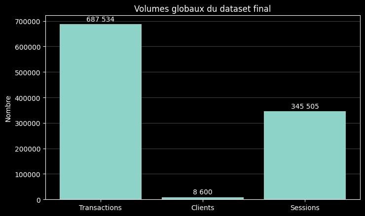

```python
# Graphique Indicateurs globaux du dataset final

plt.style.use("dark_background")

labels = ["Transactions", "Clients", "Sessions"]
values = [
    len(dataset_final),
    dataset_final["client_id"].nunique(),
    dataset_final["session_id"].nunique()
]

fig, ax = plt.subplots(figsize=(7.5, 4.5))
bars = ax.bar(labels, values)

ax.set_title("Volumes globaux du dataset final")
ax.set_ylabel("Nombre")
ax.grid(axis="y", alpha=0.25)
ax.set_axisbelow(True)

# Valeurs sur les barres
ymax = max(values)
for b, v in zip(bars, values):
    ax.text(
        b.get_x() + b.get_width()/2,
        b.get_height() + ymax*0.01,
        f"{v:,}".replace(",", " "),
        ha="center",
        va="bottom",
        fontsize=10
    )

# Valeurs "en dessous" (ligne récap)

fig.subplots_adjust(bottom=0.22)


plt.tight_layout()
plt.show()
```

```python
# Répartition par sexe

print("\n👥 Répartition par sexe :")
display(
    dataset_final["sex"]
    .value_counts()
    .rename("effectif")
    .to_frame()
    .assign(pourcentage=lambda x: round(x["effectif"] / x["effectif"].sum() * 100, 2))
)
```

```
👥 Répartition par sexe :
```

| sex | effectif | pourcentage |
| --- | --- | --- |
| m | 344841 | 50.16 |
| f | 342693 | 49.84 |

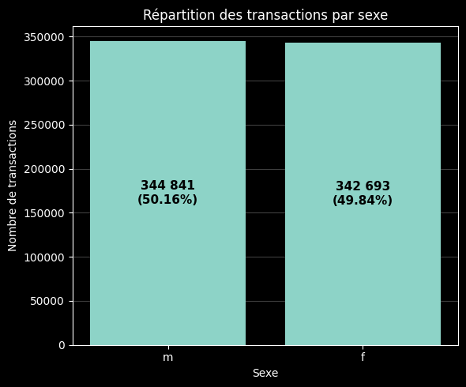

```python
# Graphique Répartion Transactions Homme / Femme
sex_counts = dataset_final["sex"].value_counts(dropna=False)
sex_pct = (sex_counts / sex_counts.sum() * 100).round(2)

# Style dark auto (gère aussi les couleurs)
plt.style.use("dark_background")

fig, ax = plt.subplots(figsize=(6, 5))
bars = ax.bar(sex_counts.index.astype(str), sex_counts.values)

ax.set_title("Répartition des transactions par sexe")
ax.set_xlabel("Sexe")
ax.set_ylabel("Nombre de transactions")
ax.grid(axis="y", alpha=0.25)
ax.set_axisbelow(True)

# Valeurs sur les barres (effectif + %)
for bar, value, pct in zip(bars, sex_counts.values, sex_pct.values):
    ax.text(
        bar.get_x() + bar.get_width() / 2,
        bar.get_height() / 2,  # centre vertical
        f"{value:,}\n({pct:.2f}%)".replace(",", " "),
        ha="center",
        va="center",
        fontsize=11,
        fontweight="bold",
        color="black"  # ou "white" selon couleur des barres
    )


plt.tight_layout()
plt.show()
```

```python
print("\n📅 Période couverte :")
print("Du", dataset_final["date"].min(), "au", dataset_final["date"].max())
```

```
📅 Période couverte :
Du 2021-03-01 00:01:07.843138 au 2023-02-28 23:58:30.792755
```

📊 **Indicateurs clés — Dataset final**

✅ **Conclusion :**  
Le dataset final est**propre techniquement** (aucune valeur manquante ni doublon exact), mais également **cohérent d’un point de vue métier**. Il permet d’analyser les comportements d’achat par client, par session et par produit.

### Étape 4.1 — Évolution du chiffre d’affaires

```python
# Préparer les données de CA (contrôle des colonnes et de la période)
df = dataset_final.copy()

# Vérifications rapides
print("Colonnes dispo :", df.columns.tolist())
print("Shape :", df.shape)

# Sécuriser les types
df["date"] = pd.to_datetime(df["date"], errors="coerce")
df["price"] = pd.to_numeric(df["price"], errors="coerce")

# Contrôle des NA
print("\nNA date :", df["date"].isna().sum())
print("NA price :", df["price"].isna().sum())

# Période couverte
print("\nPériode :", df["date"].min(), "→", df["date"].max())

# On garde uniquement les lignes exploitables pour le CA
df_ca = df.dropna(subset=["date", "price"]).copy()

# CA négatif ? (normalement non)
print("\nPrix < 0 :", (df_ca["price"] < 0).sum())
print("Prix = 0 :", (df_ca["price"] == 0).sum())
```

```
Colonnes dispo : ['id_prod', 'date', 'session_id', 'client_id', 'price', 'categ', 'sex', 'birth']
Shape : (687534, 8)

NA date : 0
NA price : 0

Période : 2021-03-01 00:01:07.843138 → 2023-02-28 23:58:30.792755

Prix < 0 : 0
Prix = 0 : 0
```

```python
# Calcul du chiffre d'affaires par jour + tendance (moyenne mobile 7j)
ca_daily = (
    df_ca
    .groupby(df_ca["date"].dt.date)["price"]
    .sum()
    .rename("ca")
    .to_frame()
)

ca_daily.index = pd.to_datetime(ca_daily.index)
ca_daily = ca_daily.sort_index()

# Ajout moyenne mobile 7 jours (tendance)
ca_daily["ca_mm7"] = ca_daily["ca"].rolling(7, min_periods=1).mean()

display(ca_daily.head())
display(ca_daily.tail())

print("Nb jours :", len(ca_daily))
print("CA total :", round(ca_daily["ca"].sum(), 2))
print("CA moyen / jour :", round(ca_daily["ca"].mean(), 2))
print("Jour max :", ca_daily["ca"].idxmax().date(), "=", round(ca_daily["ca"].max(), 2))
```

| date | ca | ca_mm7 |
| --- | --- | --- |
| 2021-03-01 | 16565.22 | 16565.2200 |
| 2021-03-02 | 15486.45 | 16025.8350 |
| 2021-03-03 | 15198.69 | 15750.1200 |
| 2021-03-04 | 15196.07 | 15611.6075 |
| 2021-03-05 | 17471.37 | 15983.5600 |

| date | ca | ca_mm7 |
| --- | --- | --- |
| 2023-02-24 | 15207.89 | 16488.778571 |
| 2023-02-25 | 15761.25 | 16006.747143 |
| 2023-02-26 | 16304.72 | 16035.021429 |
| 2023-02-27 | 19170.81 | 16487.570000 |
| 2023-02-28 | 18105.15 | 16513.984286 |

```
Nb jours : 730
CA total : 12027663.1
CA moyen / jour : 16476.25
Jour max : 2021-10-02 = 22382.43
```

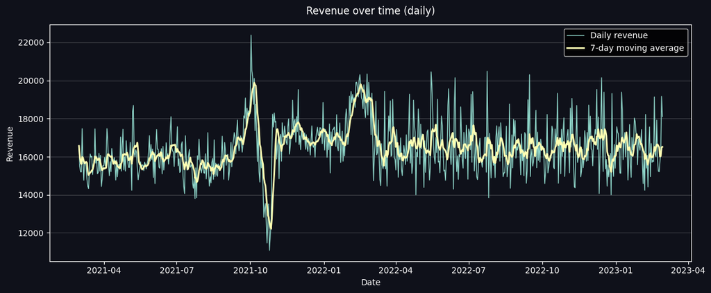

```python
# Graphique CA journalier + moyenne mobile (7 jours)
plt.figure(figsize=(12, 5), facecolor="#0f111a")
ax = plt.gca()
ax.set_facecolor("#0f111a")

ax.plot(ca_daily.index, ca_daily["ca"], linewidth=1, label="Daily revenue")
ax.plot(ca_daily.index, ca_daily["ca_mm7"], linewidth=2, label="7-day moving average")

ax.set_title("Revenue over time (daily)", color="white", pad=12)
ax.set_xlabel("Date", color="white")
ax.set_ylabel("Revenue", color="white")

ax.tick_params(colors="white")
ax.grid(axis="y", alpha=0.20)

leg = ax.legend()
for text in leg.get_texts():
    text.set_color("white")

plt.tight_layout()
plt.show()
```

```python
# Regarder la catégorie qui a eu une baisse le chiffre d'affaire et l'expliquer
# CA mensuel par catégorie
df_ca["month"] = df_ca["date"].dt.to_period("M").dt.to_timestamp()

ca_cat_month = (
    df_ca
    .groupby(["month", "categ"])["price"]
    .sum()
    .rename("ca")
    .reset_index()
    .sort_values(["categ", "month"])
)

display(ca_cat_month.head())
```

|  | month | categ | ca |
| --- | --- | --- | --- |
| 0 | 2021-03-01 | 0 | 193629.17 |
| 3 | 2021-04-01 | 0 | 205222.46 |
| 6 | 2021-05-01 | 0 | 196186.72 |
| 9 | 2021-06-01 | 0 | 167943.15 |
| 12 | 2021-07-01 | 0 | 144750.79 |

```python
# Variation mensuelle (%) par catégorie
ca_cat_month["ca_prev"] = (
    ca_cat_month
    .groupby("categ")["ca"]
    .shift(1)
)

ca_cat_month["ca_change_pct"] = (
    (ca_cat_month["ca"] - ca_cat_month["ca_prev"])
    / ca_cat_month["ca_prev"] * 100
).round(2)

display(ca_cat_month.head())
```

|  | month | categ | ca | ca_prev | ca_change_pct |
| --- | --- | --- | --- | --- | --- |
| 0 | 2021-03-01 | 0 | 193629.17 | NaN | NaN |
| 3 | 2021-04-01 | 0 | 205222.46 | 193629.17 | 5.99 |
| 6 | 2021-05-01 | 0 | 196186.72 | 205222.46 | -4.40 |
| 9 | 2021-06-01 | 0 | 167943.15 | 196186.72 | -14.40 |
| 12 | 2021-07-01 | 0 | 144750.79 | 167943.15 | -13.81 |

```python
# Détection de la plus forte baisse mensuelle du chiffre d'affaires

# On supprime les lignes sans variation calculée
ca_cat_valid = ca_cat_month.dropna(subset=["ca_change_pct"]).copy()

# Identification de la ligne correspondant à la baisse la plus importante
# (valeur minimale du pourcentage de variation)
worst_drop = ca_cat_valid.loc[
    ca_cat_valid["ca_change_pct"].idxmin()
]

print("Plus forte baisse observée :")
display(worst_drop)
```

```
Plus forte baisse observée :
```

```
month            2021-09-01 00:00:00
categ                              2
ca                          70272.99
ca_prev                    151555.79
ca_change_pct                 -53.63
Name: 20, dtype: object
```

```python
# Volume de transactions par catégorie et par mois
tx_cat_month = (
    df_ca
    .groupby(["month", "categ"])
    .size()
    .rename("transactions")
    .reset_index()
)

# Fusion avec ton CA catégorie
ca_cat_full = ca_cat_month.merge(
    tx_cat_month,
    on=["month", "categ"],
    how="left"
)

display(
    ca_cat_full[
        (ca_cat_full["categ"] == worst_drop["categ"])
        & (ca_cat_full["month"].isin([
            worst_drop["month"],
            worst_drop["month"] - pd.offsets.MonthBegin(1)
        ]))
    ]
)
```

|  | month | categ | ca | ca_prev | ca_change_pct | transactions |
| --- | --- | --- | --- | --- | --- | --- |
| 53 | 2021-08-01 | 2 | 151555.79 | 149561.34 | 1.33 | 1968 |
| 54 | 2021-09-01 | 2 | 70272.99 | 151555.79 | -53.63 | 904 |

```python
# Analyse complémentaire : panier moyen autour de la baisse

# Calcul du panier moyen (CA / nombre de transactions)
ca_cat_full["panier_moyen"] = (
    ca_cat_full["ca"] / ca_cat_full["transactions"]
).round(2)

# Affichage de la catégorie concernée
# pour le mois de la baisse et le mois précédent
display(
    ca_cat_full[
        (ca_cat_full["categ"] == worst_drop["categ"])
        & (ca_cat_full["month"].isin([
            worst_drop["month"],
            worst_drop["month"] - pd.offsets.MonthBegin(1)
        ]))
    ]
)
```

|  | month | categ | ca | ca_prev | ca_change_pct | transactions | panier_moyen |
| --- | --- | --- | --- | --- | --- | --- | --- |
| 53 | 2021-08-01 | 2 | 151555.79 | 149561.34 | 1.33 | 1968 | 77.01 |
| 54 | 2021-09-01 | 2 | 70272.99 | 151555.79 | -53.63 | 904 | 77.74 |

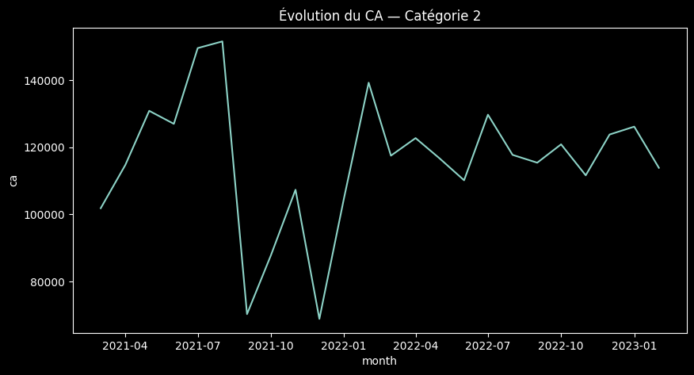

```python
# Visualisation : évolution du chiffre d'affaires
# pour la catégorie ayant subi la plus forte baisse
cat_focus = worst_drop["categ"]

plt.figure(figsize=(10,5))
sns.lineplot(
    data=ca_cat_month[ca_cat_month["categ"] == cat_focus],
    x="month",
    y="ca"
)
plt.title(f"Évolution du CA — Catégorie {cat_focus}")
plt.show()
```

📉 **Interprétation métier — Baisse du chiffre d’affaires par catégorie**

L’analyse des variations mensuelles par catégorie montre que la **catégorie 2** présente la plus forte baisse observée.

- 📅 Mois concerné : **Septembre 2021**
- 💰 CA précédent (août 2021) : **151 555 €**
- 💰 CA septembre 2021 : **70 273 €**
- 📊 Variation : **-53,63 %**

🔎 **Analyse :**  
La baisse importante du chiffre d’affaires est principalement liée à une **diminution du volume de transactions** (1968 → 904 transactions).  
Le **panier moyen reste relativement stable**, ce qui suggère que la baisse ne provient pas d’une diminution du prix moyen mais plutôt d’une **chute de la demande sur cette catégorie** durant ce mois.

✅ **Conclusion :** La chute brutale du CA en septembre 2021 pour la catégorie 2 semble s’expliquer par un **effondrement temporaire du volume de ventes**, et non par une anomalie technique ou un problème de données.

```python
# Chiffre d'affaires par mois (vue plus lisible pour le rendu)
df_ca["month"] = df_ca["date"].dt.to_period("M").dt.to_timestamp()

ca_monthly = (
    df_ca
    .groupby("month")["price"]
    .sum()
    .rename("ca")
    .to_frame()
    .sort_index()
)

# Variation mensuelle (%)
ca_monthly["ca_prev"] = ca_monthly["ca"].shift(1)
ca_monthly["ca_change_pct"] = ((ca_monthly["ca"] - ca_monthly["ca_prev"]) / ca_monthly["ca_prev"] * 100).round(2)

display(ca_monthly)

print("Mois max :", ca_monthly["ca"].idxmax().date(), "=", round(ca_monthly["ca"].max(), 2))
```

| month | ca | ca_prev | ca_change_pct |
| --- | --- | --- | --- |
| 2021-03-01 | 482440.61 | NaN | NaN |
| 2021-04-01 | 476109.30 | 482440.61 | -1.31 |
| 2021-05-01 | 492943.47 | 476109.30 | 3.54 |
| 2021-06-01 | 484088.56 | 492943.47 | -1.80 |
| 2021-07-01 | 482835.40 | 484088.56 | -0.26 |
| 2021-08-01 | 482284.79 | 482835.40 | -0.11 |
| 2021-09-01 | 507240.68 | 482284.79 | 5.17 |
| 2021-10-01 | 494733.16 | 507240.68 | -2.47 |
| 2021-11-01 | 516167.73 | 494733.16 | 4.33 |
| 2021-12-01 | 525917.28 | 516167.73 | 1.89 |
| 2022-01-01 | 525338.99 | 525917.28 | -0.11 |
| 2022-02-01 | 535571.50 | 525338.99 | 1.95 |
| 2022-03-01 | 515456.53 | 535571.50 | -3.76 |
| 2022-04-01 | 492998.94 | 515456.53 | -4.36 |
| 2022-05-01 | 517132.60 | 492998.94 | 4.90 |
| 2022-06-01 | 496016.12 | 517132.60 | -4.08 |
| 2022-07-01 | 510783.12 | 496016.12 | 2.98 |
| 2022-08-01 | 506467.27 | 510783.12 | -0.84 |
| 2022-09-01 | 494114.53 | 506467.27 | -2.44 |
| 2022-10-01 | 507917.77 | 494114.53 | 2.79 |
| 2022-11-01 | 496664.94 | 507917.77 | -2.22 |
| 2022-12-01 | 510219.50 | 496664.94 | 2.73 |
| 2023-01-01 | 517540.55 | 510219.50 | 1.43 |
| 2023-02-01 | 456679.76 | 517540.55 | -11.76 |

```
Mois max : 2022-02-01 = 535571.5
```

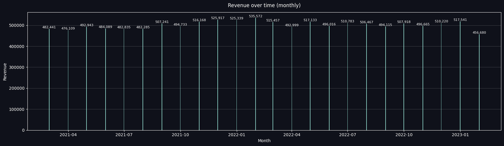

```python
# Graphique CA mensuel (avec valeurs)
plt.figure(figsize=(17, 5), facecolor="#0f111a")
ax = plt.gca()
ax.set_facecolor("#0f111a")

bars = ax.bar(ca_monthly.index, ca_monthly["ca"])

ax.set_title("Revenue over time (monthly)", color="white", pad=12)
ax.set_xlabel("Month", color="white")
ax.set_ylabel("Revenue", color="white")

ax.tick_params(colors="white")
ax.grid(axis="y", alpha=0.20)

# Afficher les valeurs au-dessus des barres
for b in bars:
    h = b.get_height()
    ax.text(b.get_x() + b.get_width()/2, h, f"{h:,.0f}", ha="center", va="bottom", fontsize=8, color="white")

plt.tight_layout()
plt.show()
```

🏠 **Étape 4.1 — Évolution du chiffre d’affaires**

📊 **Indicateurs clés — Dataset final**

- 🧾 **Transactions :** 687 534
- 👤 **Clients uniques :** 8 600
- 🔄 **Sessions uniques :** 345 505
- 👥 **Répartition par sexe :** m : 344 841( 50,16%) — f : 342 693( 49,84%)
- 📅 **Période couverte :** du 01/03/2021 au 28/02/2023 (730 jours)
- 🧪 **Contrôles qualité :** 0 valeurs manquantes sur id_prod, date, session_id, client_id, price, categ, sex, birth — 0 doublon exact

🧠 **Lecture / interprétation :**  
Le chiffre d’affaires est globalement **stable** sur l’ensemble de la période, avec un niveau moyen autour de **16,5k€ par jour**. Les courbes journalières montrent des **variations ponctuelles** (effet “bruit” naturel des ventes), tandis que la **moyenne mobile 7 jours** permet de visualiser la tendance sans les pics isolés.  
La vue mensuelle facilite la comparaison d’un mois à l’autre : on observe un **mois record en février 2022**. Enfin, la fin de période (février 2023) peut apparaître plus faible si le mois est **incomplet** selon l’extraction.

✅ **Conclusion :**  
Le dataset final est **propre techniquement** (aucune valeur manquante, aucun doublon exact) et **cohérent** pour l’analyse : il permet d’étudier les comportements d’achat **par client**, **par session** et **par produit**.

### Étape 4.2 — Moyennes mobiles

```python
# Calcul des moyennes mobiles sur le CA journalier
ca_mm = ca_daily.copy()

ca_mm["mm_7j"] = ca_mm["ca"].rolling(window=7, min_periods=1).mean()
ca_mm["mm_30j"] = ca_mm["ca"].rolling(window=30, min_periods=1).mean()
ca_mm["mm_90j"] = ca_mm["ca"].rolling(window=90, min_periods=1).mean()

display(ca_mm.head())
display(ca_mm.tail())
```

| date | ca | ca_mm7 | mm_7j | mm_30j | mm_90j |
| --- | --- | --- | --- | --- | --- |
| 2021-03-01 | 16565.22 | 16565.2200 | 16565.2200 | 16565.2200 | 16565.2200 |
| 2021-03-02 | 15486.45 | 16025.8350 | 16025.8350 | 16025.8350 | 16025.8350 |
| 2021-03-03 | 15198.69 | 15750.1200 | 15750.1200 | 15750.1200 | 15750.1200 |
| 2021-03-04 | 15196.07 | 15611.6075 | 15611.6075 | 15611.6075 | 15611.6075 |
| 2021-03-05 | 17471.37 | 15983.5600 | 15983.5600 | 15983.5600 | 15983.5600 |

| date | ca | ca_mm7 | mm_7j | mm_30j | mm_90j |
| --- | --- | --- | --- | --- | --- |
| 2023-02-24 | 15207.89 | 16488.778571 | 16488.778571 | 16238.370333 | 16494.432889 |
| 2023-02-25 | 15761.25 | 16006.747143 | 16006.747143 | 16188.068333 | 16494.061111 |
| 2023-02-26 | 16304.72 | 16035.021429 | 16035.021429 | 16162.444333 | 16467.343667 |
| 2023-02-27 | 19170.81 | 16487.570000 | 16487.570000 | 16282.368000 | 16494.029667 |
| 2023-02-28 | 18105.15 | 16513.984286 | 16513.984286 | 16321.900000 | 16493.775667 |

```python
# Indicateurs synthétiques sur les moyennes mobiles
mm_summary = {
    "MM 7j (dernier jour)": round(ca_mm["mm_7j"].iloc[-1], 2),
    "MM 30j (dernier jour)": round(ca_mm["mm_30j"].iloc[-1], 2),
    "MM 90j (dernier jour)": round(ca_mm["mm_90j"].iloc[-1], 2),
    "Écart MM 7j vs 30j (€)": round(ca_mm["mm_7j"].iloc[-1] - ca_mm["mm_30j"].iloc[-1], 2)
}

for k, v in mm_summary.items():
    print(f"- {k} : {v} €")
```

```
- MM 7j (dernier jour) : 16513.98 €
- MM 30j (dernier jour) : 16321.9 €
- MM 90j (dernier jour) : 16493.78 €
- Écart MM 7j vs 30j (€) : 192.08 €
```

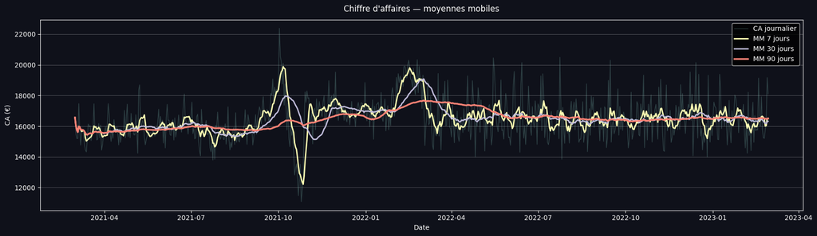

```python
# Graphique CA journalier + moyennes mobiles
plt.figure(figsize=(17, 5), facecolor="#0f111a")
ax = plt.gca()
ax.set_facecolor("#0f111a")

ax.plot(ca_mm.index, ca_mm["ca"], alpha=0.25, linewidth=1, label="CA journalier")
ax.plot(ca_mm.index, ca_mm["mm_7j"], linewidth=2, label="MM 7 jours")
ax.plot(ca_mm.index, ca_mm["mm_30j"], linewidth=2, label="MM 30 jours")
ax.plot(ca_mm.index, ca_mm["mm_90j"], linewidth=2.5, label="MM 90 jours")

ax.set_title("Chiffre d'affaires — moyennes mobiles", color="white", pad=12)
ax.set_xlabel("Date", color="white")
ax.set_ylabel("CA (€)", color="white")

ax.tick_params(colors="white")
ax.grid(axis="y", alpha=0.25)

leg = ax.legend()
for text in leg.get_texts():
    text.set_color("white")

plt.tight_layout()
plt.show()
```

📈 **Interprétation — Moyennes mobiles du chiffre d’affaires**

Ici avec la **moyenne mobile** on calcule la moyenne du chiffre d’affaires sur une période glissante (7, 30 ou 90 jours ici).  
Elle permet de **lisser les variations journalières** et de mieux visualiser la tendance générale.

🔎 **Lecture des différentes courbes :**

- **MM 7 jours** : très réactive, elle capte rapidement les pics et creux court terme.
- **MM 30 jours** : elle montre la tendance mensuelle et réduit le “bruit” quotidien.
- **MM 90 jours** : elle met en évidence la tendance structurelle de long terme.

📊 **Ce que montre le graphique :**  
• Le chiffre d’affaires journalier présente des fluctuations importantes (pics et baisses ponctuelles).  
• La moyenne mobile 7 jours lisse ces variations mais reste sensible aux événements courts.  
• Les moyennes 30 et 90 jours montrent une **stabilité globale** sur la période.  
• La chute observée fin 2021 apparaît comme un phénomène ponctuel plutôt qu’une tendance durable.

✅ **Conclusion :** Les moyennes mobiles confirment que le chiffre d’affaires est globalement **stable dans le temps**, malgré des variations court terme. Elles permettent de distinguer les **anomalies ponctuelles** des véritables évolutions structurelles.

📈 **Étape 4.2 — Moyennes mobiles (CA journalier)**

📌 Résultats clés (dernier jour disponible)

- **MM 7 jours :** 16 513,98 €
- **MM 30 jours :** 16 321,90 €
- **MM 90 jours :** 16 493,78 €
- **Écart MM 7j vs 30j :** +192,08 €

(Lecture : si la MM 7j est au-dessus de la MM 30j, la dynamique récente est légèrement plus élevée que la tendance mensuelle.)

🧠 Comment interpréter les MM ?

- **MM 7 jours** : réagit vite → capte les variations récentes (effet “court terme”).
- **MM 30 jours** : lisse davantage → donne une tendance mensuelle plus stable.
- **MM 90 jours** : très lissée → vision “long terme” (tendance de fond).

Plus la fenêtre est grande, plus la courbe est stable… mais moins elle réagit aux pics/creux récents.

✅ **Lecture rapide :**  
Les trois moyennes mobiles convergent autour de **~16,3k€ à 16,5k€**, ce qui suggère un chiffre d’affaires **globalement stable** sur la période. L’écart **MM 7j vs MM 30j** est **positif (+192€)** : la dernière semaine est donc **légèrement au-dessus** de la tendance du mois.

### Étape 4.3 — Clients, transactions, produits par période

```python
# Préparation des données (périodes + contrôles)
df = dataset_final.copy()

# Sécuriser les types
df["date"] = pd.to_datetime(df["date"], errors="coerce")
df["price"] = pd.to_numeric(df["price"], errors="coerce")

# Garder uniquement les lignes exploitables pour l'analyse par période
df_period = df.dropna(subset=["date", "price", "client_id", "id_prod"]).copy()

# Colonnes de période (jour / semaine / mois)
df_period["day"] = df_period["date"].dt.floor("D")
df_period["week"] = df_period["date"].dt.to_period("W").dt.start_time
df_period["month"] = df_period["date"].dt.to_period("M").dt.start_time

print("✅ Lignes exploitables :", len(df_period))
print("📅 Période :", df_period["day"].min().date(), "→", df_period["day"].max().date())
print("🧾 Transactions :", len(df_period))
print("👤 Clients uniques :", df_period["client_id"].nunique())
print("🛒 Produits uniques :", df_period["id_prod"].nunique())
```

```
✅ Lignes exploitables : 687534
📅 Période : 2021-03-01 → 2023-02-28
🧾 Transactions : 687534
👤 Clients uniques : 8600
🛒 Produits uniques : 3265
```

```python
# Agrégation mensuelle (Transactions / Clients / Produits)
kpi_month = (
    df_period.groupby("month")
    .agg(
        transactions=("id_prod", "size"),
        clients_uniques=("client_id", "nunique"),
        produits_uniques=("id_prod", "nunique"),
        ca=("price", "sum"),
    )
    .sort_index()
)

# Petites métriques utiles
kpi_month["ca_par_transaction"] = (kpi_month["ca"] / kpi_month["transactions"]).round(2)
kpi_month["transactions_par_client"] = (kpi_month["transactions"] / kpi_month["clients_uniques"]).round(2)

display(kpi_month.head(6))
display(kpi_month.tail(6))

print("✅ Nombre de mois :", len(kpi_month))
print("📈 Mois max transactions :", kpi_month["transactions"].idxmax().date(), "-", int(kpi_month["transactions"].max()))
print("👥 Mois max clients :", kpi_month["clients_uniques"].idxmax().date(), "-", int(kpi_month["clients_uniques"].max()))
print("🛍️ Mois max produits uniques :", kpi_month["produits_uniques"].idxmax().date(), "-", int(kpi_month["produits_uniques"].max()))
```

| month | transactions | clients_uniques | produits_uniques | ca | ca_par_transaction | transactions_par_client |
| --- | --- | --- | --- | --- | --- | --- |
| 2021-03-01 | 28601 | 5676 | 2482 | 482440.61 | 16.87 | 5.04 |
| 2021-04-01 | 28443 | 5674 | 2492 | 476109.30 | 16.74 | 5.01 |
| 2021-05-01 | 28285 | 5644 | 2471 | 492943.47 | 17.43 | 5.01 |
| 2021-06-01 | 26850 | 5659 | 2414 | 484088.56 | 18.03 | 4.74 |
| 2021-07-01 | 24738 | 5672 | 2369 | 482835.40 | 19.52 | 4.36 |
| 2021-08-01 | 25650 | 5642 | 2404 | 482284.79 | 18.80 | 4.55 |

| month | transactions | clients_uniques | produits_uniques | ca | ca_par_transaction | transactions_par_client |
| --- | --- | --- | --- | --- | --- | --- |
| 2022-09-01 | 28306 | 5738 | 2452 | 494114.53 | 17.46 | 4.93 |
| 2022-10-01 | 28964 | 5755 | 2489 | 507917.77 | 17.54 | 5.03 |
| 2022-11-01 | 28563 | 5749 | 2448 | 496664.94 | 17.39 | 4.97 |
| 2022-12-01 | 28619 | 5765 | 2438 | 510219.50 | 17.83 | 4.96 |
| 2023-01-01 | 28938 | 5828 | 2488 | 517540.55 | 17.88 | 4.97 |
| 2023-02-01 | 25545 | 5587 | 2407 | 456679.76 | 17.88 | 4.57 |

```
✅ Nombre de mois : 24
📈 Mois max transactions : 2021-09-01 - 33314
👥 Mois max clients : 2021-10-01 - 6190
🛍️ Mois max produits uniques : 2021-09-01 - 2560
```

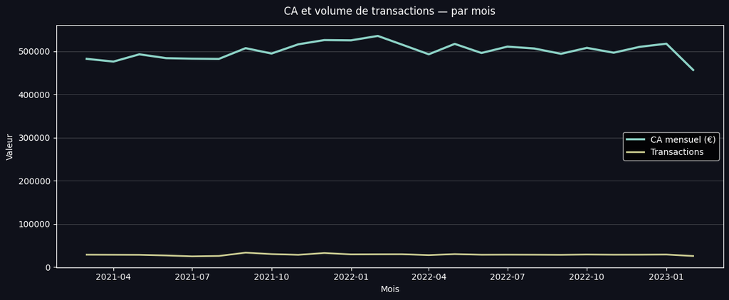

```python
# Graphique CA mensuel + Transactions
plt.figure(figsize=(12, 5), facecolor="#0f111a")
ax = plt.gca()
ax.set_facecolor("#0f111a")

ax.plot(kpi_month.index, kpi_month["ca"], linewidth=2.5, label="CA mensuel (€)")
ax.plot(kpi_month.index, kpi_month["transactions"], linewidth=2, alpha=0.8, label="Transactions")

ax.set_title("CA et volume de transactions — par mois", color="white", pad=12)
ax.set_xlabel("Mois", color="white")
ax.set_ylabel("Valeur", color="white")
ax.tick_params(colors="white")
ax.grid(axis="y", alpha=0.20)

leg = ax.legend()
for t in leg.get_texts():
    t.set_color("white")

plt.tight_layout()
plt.show()
```

```python
# Synthèse (valeurs clés)
nb_months = len(kpi_month)

month_max_tx = kpi_month["transactions"].idxmax().date()
max_tx = int(kpi_month["transactions"].max())

month_max_clients = kpi_month["clients_uniques"].idxmax().date()
max_clients = int(kpi_month["clients_uniques"].max())

month_max_prods = kpi_month["produits_uniques"].idxmax().date()
max_prods = int(kpi_month["produits_uniques"].max())

avg_tx_month = int(round(kpi_month["transactions"].mean(), 0))
avg_clients_month = int(round(kpi_month["clients_uniques"].mean(), 0))
avg_prods_month = int(round(kpi_month["produits_uniques"].mean(), 0))

avg_tx_per_client = round(kpi_month["transactions_par_client"].mean(), 2)
avg_ca_per_tx = round(kpi_month["ca_par_transaction"].mean(), 2)

print("📌 Résumé Étape 4.3")
print("- Mois analysés :", nb_months)
print("- Moyenne transactions/mois :", avg_tx_month)
print("- Moyenne clients uniques/mois :", avg_clients_month)
print("- Moyenne produits uniques/mois :", avg_prods_month)
print("- Moyenne transactions/client (mensuel) :", avg_tx_per_client)
print("- Panier moyen (CA/transaction) :", avg_ca_per_tx, "€")
print("- Pic transactions :", month_max_tx, "-", max_tx)
print("- Pic clients :", month_max_clients, "-", max_clients)
print("- Pic produits uniques :", month_max_tx, "-", max_prods)
```

```
📌 Résumé Étape 4.3
- Mois analysés : 24
- Moyenne transactions/mois : 28647
- Moyenne clients uniques/mois : 5759
- Moyenne produits uniques/mois : 2463
- Moyenne transactions/client (mensuel) : 4.97
- Panier moyen (CA/transaction) : 17.54 €
- Pic transactions : 2021-09-01 - 33314
- Pic clients : 2021-10-01 - 6190
- Pic produits uniques : 2021-09-01 - 2560
```

📅 **Synthèse — Clients, transactions, produits par période (Étape 4.3)**

📌 **Période analysée :** 2021-03-01→ 2023-02-28 (données journalières agrégées ensuite au mois)

🗓️ **Nombre de mois analysés :** 24

📊 Moyennes mensuelles (activité)

Transactions / mois : 28 647

Clients uniques / mois : 5 759

Produits uniques / mois : 2 463

🧾 Indicateurs “métier”

Transactions / client (mensuel) : 4.97

🚀 Mois “records” observés

Pic transactions : 2021-09-01 — 33 314

Pic clients uniques : 2021-10-01 — 6 190

Pic produits uniques : 2021-09-01 — 2 560

✅ **Lecture rapide :**  
Sur 24 mois, l’activité est globalement **stable** : ~**28,6k** transactions/mois et ~**5,8k** clients uniques/mois. Les pics se concentrent autour de **septembre–octobre 2021**, ce qui peut traduire une période plus active (campagne, saisonnalité, ou effet d’acquisition). Le panier moyen (~**17,54 €**) sert de repère “métier” pour comparer les périodes entre elles.

## Étape 5 — Analyse de la performance des produits

### Étape 5.1 — Tops produits

```python
# Top Produits — CA & Volume
top_products = (
    df_ca
    .groupby("id_prod")
    .agg(
        ca_total=("price", "sum"),
        transactions=("price", "size")
    )
    .reset_index()
)

# Tri
top_ca = top_products.sort_values("ca_total", ascending=False).head(10)
top_volume = top_products.sort_values("transactions", ascending=False).head(10)

display(top_ca)
display(top_volume)
```

|  | id_prod | ca_total | transactions |
| --- | --- | --- | --- |
| 3096 | 2_159 | 94893.50 | 650 |
| 3070 | 2_135 | 69334.95 | 1005 |
| 3045 | 2_112 | 65407.76 | 968 |
| 3034 | 2_102 | 60736.78 | 1027 |
| 3152 | 2_209 | 56971.86 | 814 |
| 2619 | 1_395 | 56617.47 | 1953 |
| 2591 | 1_369 | 56136.60 | 2340 |
| 3043 | 2_110 | 53846.25 | 865 |
| 2607 | 1_383 | 53834.43 | 1857 |
| 2641 | 1_414 | 53522.18 | 2246 |

|  | id_prod | ca_total | transactions |
| --- | --- | --- | --- |
| 2591 | 1_369 | 56136.60 | 2340 |
| 2644 | 1_417 | 47626.31 | 2269 |
| 2641 | 1_414 | 53522.18 | 2246 |
| 2733 | 1_498 | 51460.74 | 2202 |
| 2653 | 1_425 | 36749.37 | 2163 |
| 2629 | 1_403 | 36699.60 | 2040 |
| 2640 | 1_413 | 36627.64 | 2036 |
| 2639 | 1_412 | 33533.10 | 2014 |
| 2632 | 1_406 | 49694.43 | 2003 |
| 2633 | 1_407 | 31995.99 | 2001 |

```python
# TOP PRODUITS — Triés par nombre de ventes

# Agrégation CA + volume
top_products_volume = (
    df_ca
    .groupby("id_prod")
    .agg(
        ca_total=("price", "sum"),
        transactions=("price", "size")
    )
    .reset_index()
)

# Tri décroissant par nombre de transactions
top_volume = (
    top_products_volume
    .sort_values("transactions", ascending=False)
    .head(10)
)

display(top_volume)
```

|  | id_prod | ca_total | transactions |
| --- | --- | --- | --- |
| 2591 | 1_369 | 56136.60 | 2340 |
| 2644 | 1_417 | 47626.31 | 2269 |
| 2641 | 1_414 | 53522.18 | 2246 |
| 2733 | 1_498 | 51460.74 | 2202 |
| 2653 | 1_425 | 36749.37 | 2163 |
| 2629 | 1_403 | 36699.60 | 2040 |
| 2640 | 1_413 | 36627.64 | 2036 |
| 2639 | 1_412 | 33533.10 | 2014 |
| 2632 | 1_406 | 49694.43 | 2003 |
| 2633 | 1_407 | 31995.99 | 2001 |

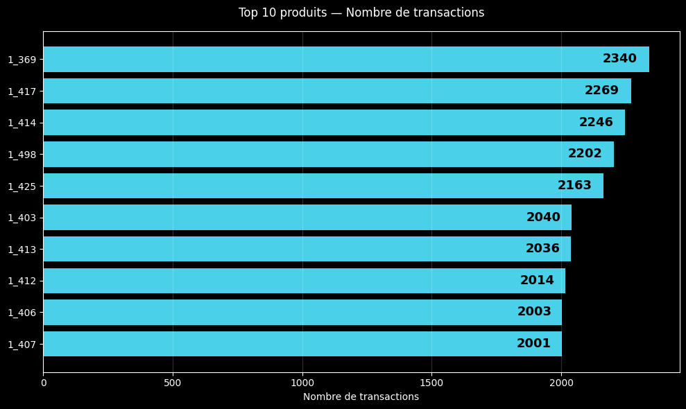

```python
# Graphique : Top 10 produits classés par volume de ventes.
# Permet d’identifier les produits les plus populaires,
# indépendamment de leur contribution au chiffre d’affaires.
plt.style.use("dark_background")

fig, ax = plt.subplots(figsize=(10,6))

bars = ax.barh(
    top_volume["id_prod"].astype(str),
    top_volume["transactions"],
    color="#4ad0e8"
)

ax.set_title("Top 10 produits — Nombre de transactions", pad=15)
ax.set_xlabel("Nombre de transactions")
ax.invert_yaxis()
ax.grid(axis="x", alpha=0.2)

# Valeurs dans les barres
for bar in bars:
    width = bar.get_width()
    ax.text(
        width * 0.98,
        bar.get_y() + bar.get_height()/2,
        f"{int(width)}",
        va="center",
        ha="right",
        fontsize=13,
        fontweight="bold",
        color="black"
    )

plt.tight_layout()
plt.show()
```

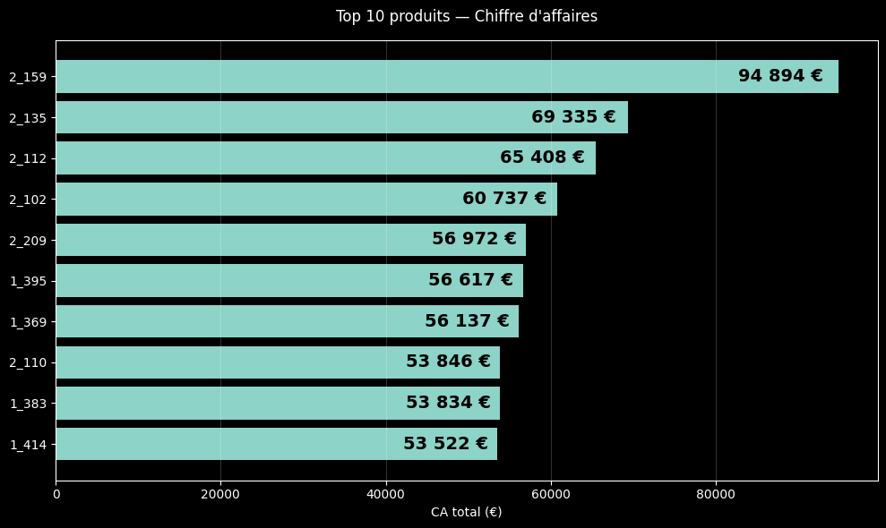

```python
# Graphique : Top 10 produits les plus rentables montrant une forte concentration des revenus parmi les articles phares
plt.style.use("dark_background")

fig, ax = plt.subplots(figsize=(10,6))

bars = ax.barh(
    top_ca["id_prod"].astype(str),
    top_ca["ca_total"],
)

ax.set_title("Top 10 produits — Chiffre d'affaires", pad=15)
ax.set_xlabel("CA total (€)")
ax.invert_yaxis()
ax.grid(axis="x", alpha=0.2)

# Valeurs dans les barres
for bar in bars:
    width = bar.get_width()
    ax.text(
        width * 0.98,
        bar.get_y() + bar.get_height()/2,
        f"{width:,.0f} €".replace(",", " "),
        va="center",
        ha="right",
        fontsize=14,
        fontweight="bold",
        color="black"
    )

plt.tight_layout()
plt.show()
```

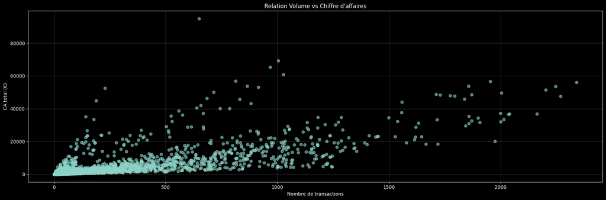

```python
# Revenus vs Volume de Transactions (Produits phares)
# Nuage de points montrant la relation entre le volume des ventes et le revenu total
# Et le revenu total met en évidence les produits à fort volume et forte valeur
fig, ax = plt.subplots(figsize=(18,6))

ax.scatter(
    top_products["transactions"],
    top_products["ca_total"],
    alpha=0.6
)

ax.set_title("Relation Volume vs Chiffre d'affaires")
ax.set_xlabel("Nombre de transactions")
ax.set_ylabel("CA total (€)")
ax.grid(alpha=0.2)

plt.tight_layout()
plt.show()
```

🏆 **Étape 5.1 — Analyse des Tops produits**

L’analyse des **10 produits générant le plus de chiffre d’affaires** met en évidence une forte concentration du revenu sur un nombre limité d’articles.

- 💰 Le produit le plus performant dépasse largement les autres en CA, ce qui suggère un **effet “produit star”**.
- 📦 Certains produits affichent un **volume élevé de transactions** mais un CA plus modéré : ils contribuent via la quantité.
- 💎 D’autres génèrent un CA important avec moins de transactions : cela indique un **panier moyen élevé**.

🔎 **Lecture stratégique :**  
La relation entre volume de transactions et chiffre d’affaires montre une corrélation positive globale : plus un produit est acheté, plus il génère de CA. Cependant, les écarts observés suggèrent l’existence de **segments produits différents** :

- Produits à forte rotation (volume élevé)
- Produits premium (fort CA unitaire)

✅ **Conclusion :**  
Les performances ne reposent pas uniquement sur le volume. La combinaison **prix × fréquence d’achat** détermine la contribution réelle au chiffre d’affaires. Cette analyse peut servir de base pour :

- Optimisation du catalogue
- Stratégie promotionnelle ciblée
- Gestion des stocks stratégiques

### Étape 5.2 — Flops produits

```python
# Flops Produits — CA & Volume
flop_products = (
    df_ca
    .groupby("id_prod")
    .agg(
        ca_total=("price", "sum"),
        transactions=("price", "size")
    )
    .reset_index()
)

# Filtrer produits avec au moins 10 ventes
flop_products = flop_products[flop_products["transactions"] >= 10]

# Tri croissant
flop_ca = flop_products.sort_values("ca_total", ascending=True).head(10)

display(flop_ca)
```

|  | id_prod | ca_total | transactions |
| --- | --- | --- | --- |
| 1256 | 0_2138 | 9.30 | 10 |
| 224 | 0_1203 | 9.90 | 10 |
| 362 | 0_1329 | 9.90 | 10 |
| 220 | 0_120 | 9.90 | 15 |
| 850 | 0_1771 | 9.90 | 10 |
| 881 | 0_180 | 10.67 | 11 |
| 2193 | 0_91 | 10.89 | 11 |
| 450 | 0_1408 | 13.13 | 13 |
| 1445 | 0_232 | 14.76 | 12 |
| 1407 | 0_2275 | 14.85 | 15 |

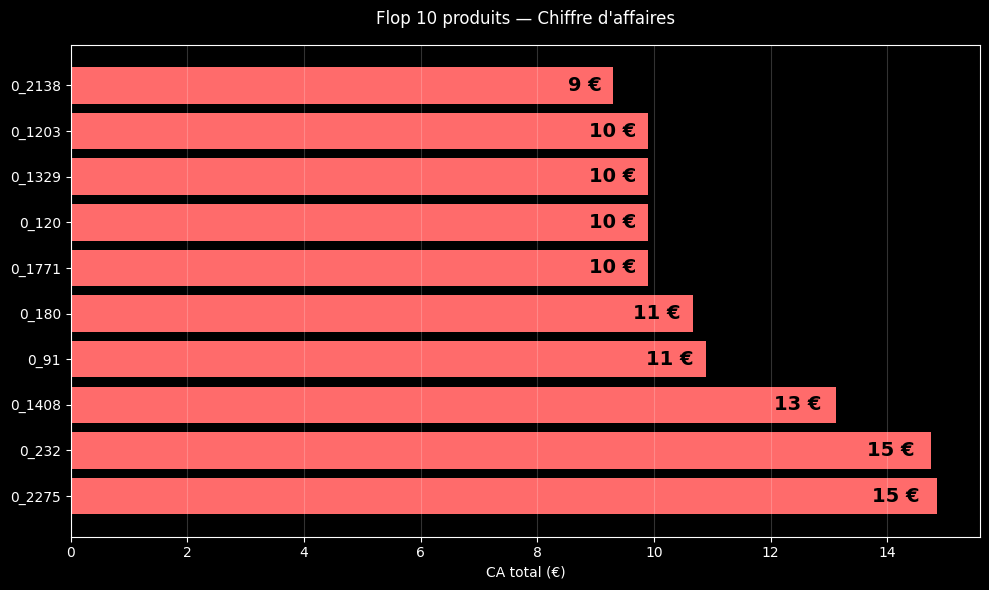

```python
# Graphique : Flop 10 produits, montrant une contribution minimale aux ventes totales
plt.style.use("dark_background")

fig, ax = plt.subplots(figsize=(10,6))

bars = ax.barh(
    flop_ca["id_prod"].astype(str),
    flop_ca["ca_total"],
    color="#ff6b6b"
)

ax.set_title("Flop 10 produits — Chiffre d'affaires", pad=15)
ax.set_xlabel("CA total (€)")
ax.invert_yaxis()
ax.grid(axis="x", alpha=0.2)

# Valeurs dans les barres
for bar in bars:
    width = bar.get_width()
    ax.text(
        width * 0.98,
        bar.get_y() + bar.get_height()/2,
        f"{width:,.0f} €".replace(",", " "),
        va="center",
        ha="right",
        fontsize=14,
        fontweight="bold",
        color="black"
    )

plt.tight_layout()
plt.show()
```

```python
# Flop trié par nombre de produits dans l'ordre

# Agrégation CA + volume par produit
flop_products = (
    df_ca
    .groupby("id_prod")
    .agg(
        ca_total=("price", "sum"),
        transactions=("price", "size")
    )
    .reset_index()
)

# ✅ Filtre : on garde les produits avec au moins 10 ventes (réduit le "bruit")
flop_products_filtered = flop_products[flop_products["transactions"] >= 10].copy()

# Tri croissant par volume (transactions) puis CA (pour départager si égalité)
flop_by_volume = (
    flop_products_filtered
    .sort_values(["transactions", "ca_total"], ascending=[True, True])
    .head(10)
)

display(flop_by_volume)
```

|  | id_prod | ca_total | transactions |
| --- | --- | --- | --- |
| 1256 | 0_2138 | 9.3 | 10 |
| 224 | 0_1203 | 9.9 | 10 |
| 362 | 0_1329 | 9.9 | 10 |
| 850 | 0_1771 | 9.9 | 10 |
| 1390 | 0_226 | 14.9 | 10 |
| 1451 | 0_238 | 16.7 | 10 |
| 2222 | 0_936 | 16.9 | 10 |
| 1214 | 0_210 | 18.7 | 10 |
| 15 | 0_1010 | 19.6 | 10 |
| 1348 | 0_2220 | 24.1 | 10 |

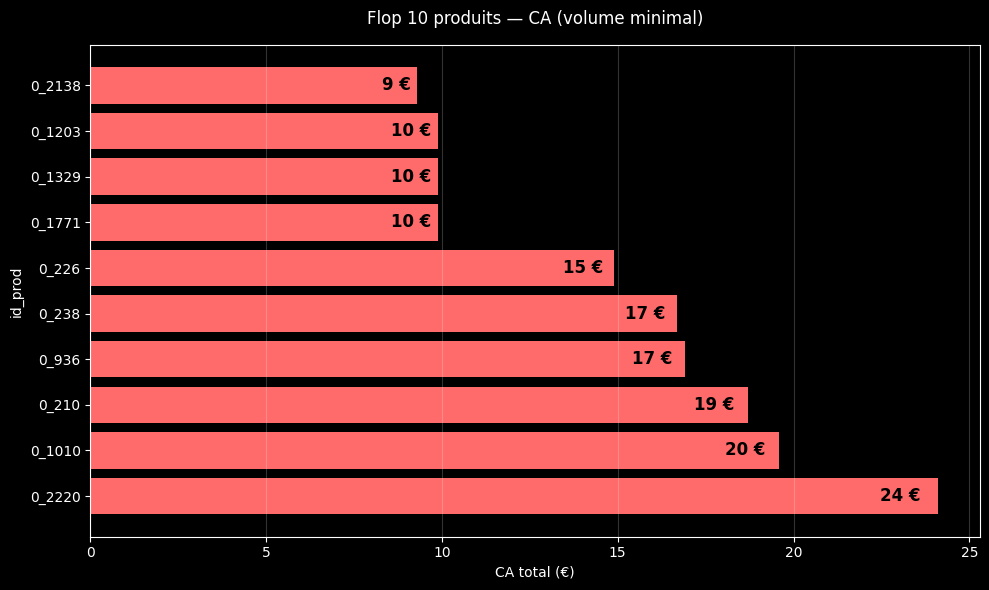

```python
# Graphique : Flop 10 produits (volume minimal) — CA total
# Ici plusieurs produits ont le même volume (ex: 10 ventes)
# On garde le classement par volume, mais on affiche le CA total
plt.style.use("dark_background")

fig, ax = plt.subplots(figsize=(10, 6))

bars = ax.barh(
    flop_by_volume["id_prod"].astype(str),
    flop_by_volume["ca_total"],
    color="#ff6b6b"
)

ax.set_title("Flop 10 produits — CA (volume minimal)", pad=15)
ax.set_xlabel("CA total (€)")
ax.set_ylabel("id_prod")
ax.invert_yaxis()
ax.grid(axis="x", alpha=0.2)

# Valeurs sur les barres
for bar in bars:
    width = bar.get_width()
    ax.text(
        width * 0.98,
        bar.get_y() + bar.get_height() / 2,
        f"{width:,.0f} €".replace(",", " "),
        va="center",
        ha="right",
        fontsize=12,
        fontweight="bold",
        color="black"
    )

plt.tight_layout()
plt.show()
```

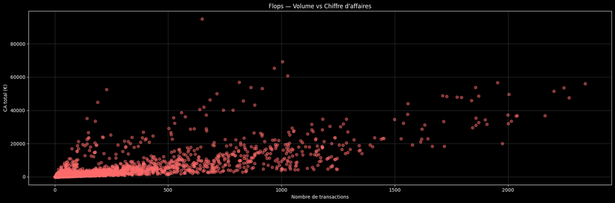

```python
# Graphique : 10 produits les moins performants par revenu total (avec filtre de volume minimal)
# Produits peu performants filtrés pour éviter le bruit
# Utilisé pour détecter les articles faibles du catalogue
fig, ax = plt.subplots(figsize=(18,6))

ax.scatter(
    flop_products["transactions"],
    flop_products["ca_total"],
    alpha=0.5,
    color="#ff6b6b"
)

ax.set_title("Flops — Volume vs Chiffre d'affaires")
ax.set_xlabel("Nombre de transactions")
ax.set_ylabel("CA total (€)")
ax.grid(alpha=0.2)

plt.tight_layout()
plt.show()
```

📉 **Étape 5.2 — Analyse des Flops produits**

Les flops produits correspondent ici aux articles ayant généré le **plus faible chiffre d’affaires**, tout en ayant réalisé **au moins 10 transactions**.

- 📦 Ces produits ne sont pas inexistants dans le catalogue : ils génèrent **un certain volume** mais une **valeur globale très faible**.
- 💰 Leur contribution au chiffre d’affaires total reste **marginale**.
- ⚖️ Certains présentent un **panier moyen très faible**, ce qui limite leur impact financier.

🔎 **Lecture stratégique :**  
Ces produits peuvent révéler :

- Un positionnement prix inadapté
- Un manque de visibilité marketing
- Une faible attractivité produit
- Un article en fin de cycle de vie

✅ **Recommandation métier :**  
Avant suppression du catalogue, il convient d’analyser :

- La marge unitaire associée
- La saisonnalité
- Le positionnement tarifaire
- Les opportunités de repositionnement marketing

### Étape 5.3 — Répartition du CA par catégorie

```python
# CA par Catégorie

ca_categ = (
    df_ca
    .groupby("categ")["price"]
    .sum()
    .rename("ca_total")
    .reset_index()
)

# Pourcentage du total
total_ca = ca_categ["ca_total"].sum()
ca_categ["part_pct"] = (ca_categ["ca_total"] / total_ca * 100).round(2)

# Tri décroissant
ca_categ = ca_categ.sort_values("ca_total", ascending=False)

display(ca_categ)
```

|  | categ | ca_total | part_pct |
| --- | --- | --- | --- |
| 1 | 1 | 4827657.11 | 40.14 |
| 0 | 0 | 4419730.97 | 36.75 |
| 2 | 2 | 2780275.02 | 23.12 |

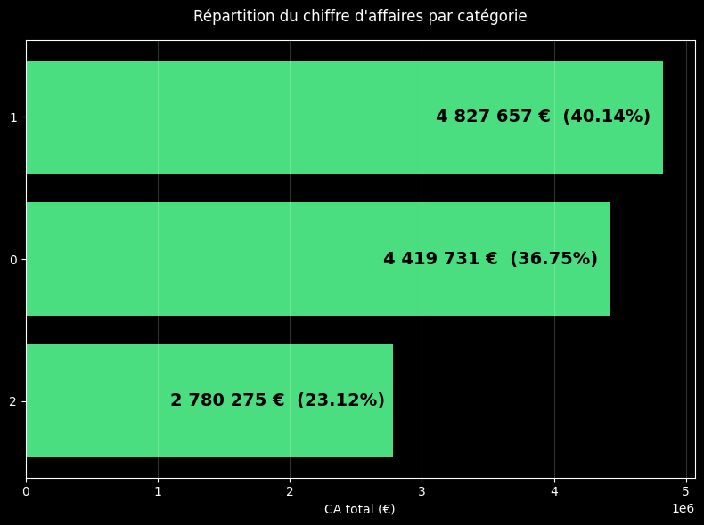

```python
# Graphique : Répartition des revenus par catégorie
# Affiche la part des revenus totaux (%) pour chaque catégorie
# Utilisé pour détecter les risques de concentration et les segments dominants
plt.style.use("dark_background")

fig, ax = plt.subplots(figsize=(8,6))

bars = ax.barh(
    ca_categ["categ"].astype(str),
    ca_categ["ca_total"],
    color="#4ade80"
)

ax.set_title("Répartition du chiffre d'affaires par catégorie", pad=15)
ax.set_xlabel("CA total (€)")
ax.invert_yaxis()
ax.grid(axis="x", alpha=0.2)

# Valeurs dans les barres
for bar, pct in zip(bars, ca_categ["part_pct"]):
    width = bar.get_width()
    ax.text(
        width * 0.98,
        bar.get_y() + bar.get_height()/2,
        f"{width:,.0f} €  ({pct}%)".replace(",", " "),
        va="center",
        ha="right",
        fontsize=14,
        fontweight="bold",
        color="black"
    )

plt.tight_layout()
plt.show()
```

📊 **Étape 5.3 — Analyse de la répartition du CA par catégorie**

L’analyse montre que le chiffre d’affaires n’est pas réparti uniformément entre les catégories.

- 🥇 La catégorie dominante représente environ **40 %** du CA total.
- 🥈 La seconde catégorie pèse près de **37 %**.
- 🥉 La troisième catégorie contribue encore à hauteur de **23 %**.

👉 **Lecture stratégique :** La concentration est réelle mais modérée. Deux catégories génèrent environ **77 % du chiffre d’affaires**, ce qui suggère une structure relativement équilibrée plutôt qu’un effet Pareto extrême (80/20).

✅ **Conclusion :** L’entreprise repose principalement sur deux catégories fortes, tout en conservant une troisième catégorie significative. Cela limite le risque de dépendance excessive à un seul segment.

## Étape 6 — Analyse des clients

### Étape 6.1 — Profils clients & données démographiques

```python
# PROFIL CLIENT — Répartition par genre
client_profile = (
    dataset_final
    .groupby("sex")
    .agg(
        transactions=("price", "size"),
        ca_total=("price", "sum")
    )
    .reset_index()
)

client_profile["part_transactions_pct"] = (
    client_profile["transactions"] / client_profile["transactions"].sum() * 100
).round(2)

display(client_profile)
```

|  | sex | transactions | ca_total | part_transactions_pct |
| --- | --- | --- | --- | --- |
| 0 | f | 342693 | 5950843.68 | 49.84 |
| 1 | m | 344841 | 6076819.42 | 50.16 |

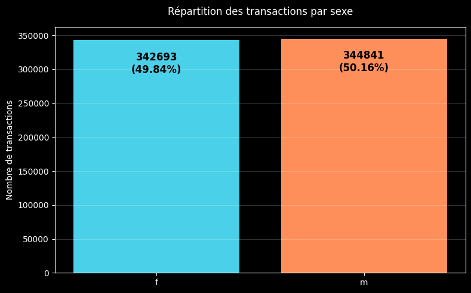

```python
# Graphique PROFIL CLIENT — Répartition par sexe
plt.style.use("dark_background")

fig, ax = plt.subplots(figsize=(8,5))

bars = ax.bar(
    client_profile["sex"].astype(str),
    client_profile["transactions"],
    color=["#4ad0e8", "#ff8f5a"]
)

ax.set_title("Répartition des transactions par sexe", pad=15)
ax.set_ylabel("Nombre de transactions")
ax.grid(axis="y", alpha=0.2)

for bar, pct in zip(bars, client_profile["part_transactions_pct"]):
    height = bar.get_height()
    ax.text(
        bar.get_x() + bar.get_width()/2,
        height*0.95,
        f"{int(height)}\n({pct}%)",
        ha="center",
        va="top",
        fontsize=12,
        fontweight="bold",
        color="black"
    )

plt.tight_layout()
plt.show()
```

```python
# Panier moyen par sexe
client_profile["panier_moyen"] = (
    client_profile["ca_total"] / client_profile["transactions"]
).round(2)

display(client_profile)
```

|  | sex | transactions | ca_total | part_transactions_pct | panier_moyen |
| --- | --- | --- | --- | --- | --- |
| 0 | f | 342693 | 5950843.68 | 49.84 | 17.36 |
| 1 | m | 344841 | 6076819.42 | 50.16 | 17.62 |

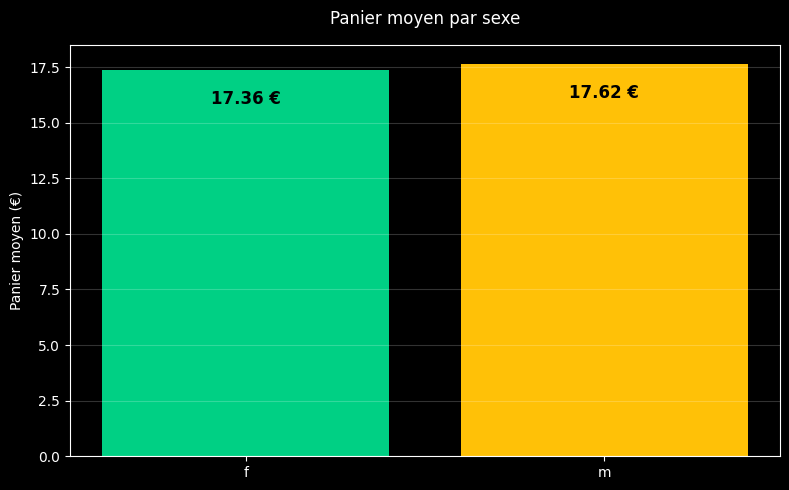

```python
# Graphique panier moyen par sexe
fig, ax = plt.subplots(figsize=(8,5))

bars = ax.bar(
    client_profile["sex"].astype(str),
    client_profile["panier_moyen"],
    color=["#00d084", "#ffc107"]
)

ax.set_title("Panier moyen par sexe", pad=15)
ax.set_ylabel("Panier moyen (€)")
ax.grid(axis="y", alpha=0.2)

for bar in bars:
    height = bar.get_height()
    ax.text(
        bar.get_x() + bar.get_width()/2,
        height*0.95,
        f"{height:.2f} €",
        ha="center",
        va="top",
        fontsize=12,
        fontweight="bold",
        color="black"
    )

plt.tight_layout()
plt.show()
```

```python
# Agrégation des données par client
# Calcul du nombre de transactions et du chiffre d'affaires total par client
client_freq = dataset_final.groupby("client_id").agg(
    transactions=("price","size"),
    ca_total=("price","sum")
)

display(client_freq)
```

| client_id | transactions | ca_total |
| --- | --- | --- |
| c_1 | 43 | 629.02 |
| c_10 | 58 | 1353.60 |
| c_100 | 8 | 254.85 |
| c_1000 | 126 | 2291.88 |
| c_1001 | 103 | 1823.85 |
| ... | ... | ... |
| c_995 | 14 | 189.41 |
| c_996 | 96 | 1637.34 |
| c_997 | 59 | 1490.01 |
| c_998 | 55 | 2822.22 |
| c_999 | 46 | 701.40 |

8600 rows × 2 columns

```python
# Segmentation clients : fréquence d'achat

# Sécurité: date en datetime
dataset_final["date"] = pd.to_datetime(dataset_final["date"], errors="coerce")

# Stats par client
client_stats = (
    dataset_final.groupby("client_id")
    .agg(
        nb_transactions=("price", "size"),
        ca_total=("price", "sum"),
        first_purchase=("date", "min"),
    )
    .reset_index()
)

# 1) Actifs vs occasionnels (simple)
client_stats["segment"] = np.where(client_stats["nb_transactions"] == 1, "Occasionnel", "Actif")
segment_summary = (
    client_stats["segment"].value_counts()
    .rename_axis("segment")
    .reset_index(name="nb_clients")
)

display(segment_summary)
```

|  | segment | nb_clients |
| --- | --- | --- |
| 0 | Actif | 8594 |
| 1 | Occasionnel | 6 |

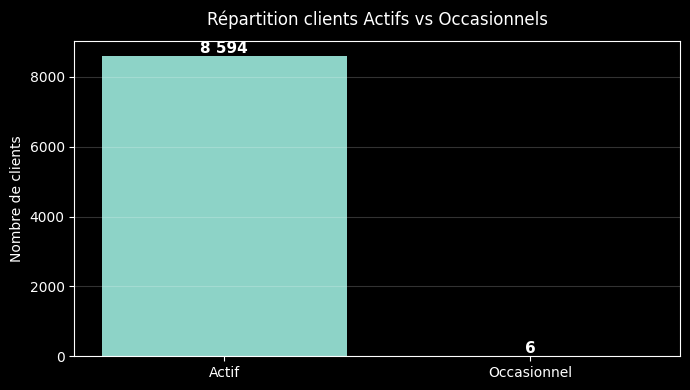

```
➡️ Clients actifs : 8 594
➡️ Clients occasionnels : 6
```

```python
# Graphique Segmentation clients : fréquence d'achat

# Graph 1: Actif vs Occasionnel
fig, ax = plt.subplots(figsize=(7,4))
x = segment_summary["segment"].astype(str).tolist()
y = segment_summary["nb_clients"].astype(int).tolist()

bars = ax.bar(x, y)
ax.set_title("Répartition clients Actifs vs Occasionnels", pad=12)
ax.set_ylabel("Nombre de clients")
ax.grid(axis="y", alpha=0.2)

for b in bars:
    val = int(b.get_height())
    ax.text(
        b.get_x() + b.get_width()/2,
        b.get_height(),
        f"{val:,}".replace(",", " "),
        ha="center",
        va="bottom",
        fontsize=11,
        fontweight="bold"
    )

plt.tight_layout()
plt.show()

actif_n = int(segment_summary.loc[segment_summary["segment"]=="Actif","nb_clients"].sum())
occ_n   = int(segment_summary.loc[segment_summary["segment"]=="Occasionnel","nb_clients"].sum())
print(f"➡️ Clients actifs : {actif_n:,}".replace(",", " "))
print(f"➡️ Clients occasionnels : {occ_n:,}".replace(",", " "))
print()
```

```python
# Ancienneté client (règle des 6 mois)
date_ref = dataset_final["date"].max()
limit = date_ref - pd.DateOffset(months=6)

client_stats["seniority"] = np.where(
    client_stats["first_purchase"] >= limit,
    "Nouveau client",
    "Client existant"
)

seniority_summary = client_stats["seniority"].value_counts().reset_index()
seniority_summary.columns = ["seniority", "nb_clients"]

display(seniority_summary)

print("\nRépartition par ancienneté client:")
print(seniority_summary)
```

|  | seniority | nb_clients |
| --- | --- | --- |
| 0 | Client existant | 8600 |

```
Répartition par ancienneté client:
         seniority  nb_clients
0  Client existant        8600
```

```python
# Revenu moyen par ancienneté client
ca_moyen = client_stats.groupby("seniority")["ca_total"].mean().reset_index()
ca_moyen.columns = ["seniority", "avg_revenue"]

display(ca_moyen)

print("\nRevenu moyen par ancienneté client:")
print(ca_moyen)
```

|  | seniority | avg_revenue |
| --- | --- | --- |
| 0 | Client existant | 1398.565477 |

```
Revenu moyen par ancienneté client:
         seniority  avg_revenue
0  Client existant  1398.565477
```

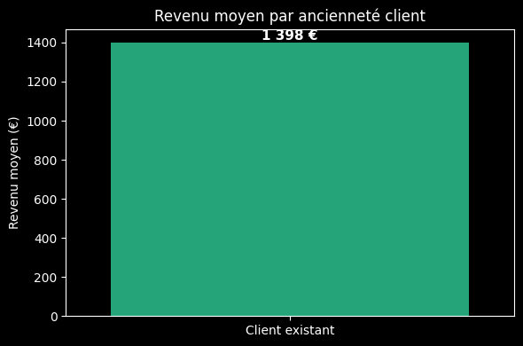

|  | seniority | avg_revenue |
| --- | --- | --- |
| 0 | Client existant | 1398.565477 |

```python
# Graphique revenu moyen par ancienneté client (juste afficher le chiffre supprimer le graphique !!!!)
plt.figure(figsize=(6,4))

ax = sns.barplot(
    data=ca_moyen,
    x="seniority",
    y="avg_revenue",
    hue="seniority",
    legend=False,
    palette={"Nouveau client":"#f97316", "Client existant":"#10b981"}
)

for p in ax.patches:
    ax.annotate(
        f"{int(p.get_height()):,} €".replace(",", " "),
        (p.get_x() + p.get_width()/2, p.get_height()),
        ha="center",
        va="bottom",
        fontsize=11,
        fontweight="bold"
    )

plt.title("Revenu moyen par ancienneté client")
plt.ylabel("Revenu moyen (€)")
plt.xlabel("")
plt.tight_layout()
plt.show()

display(ca_moyen.reset_index(drop=True))
```

👥 **Étape 6 — Analyse des profils clients & segmentation comportementale**

L’analyse client met en évidence une forte concentration du portefeuille autour de clients actifs et anciens.

👉 **Lecture stratégique :**  
La performance économique repose principalement sur une base de clients fidèles. Le levier prioritaire n’est donc pas uniquement l’acquisition, mais aussi la rétention et l’augmentation de la valeur client.

✅ **Conclusion :**  
Le modèle repose sur une forte fidélisation. L’enjeu stratégique consiste à optimiser le panier moyen et à sécuriser la base client existante.

### Étape 6.2 — Concentration du CA & courbe de Lorenz

```python
# Concentration du CA
# Calcul du chiffre d'affaires par client
print("Étape 6.2 — Concentration du chiffre d'affaires\n")

# Agrégation CA par client
ca_client = (
    dataset_final
    .groupby("client_id")["price"]
    .sum()
    .reset_index(name="ca_total")
)

display(ca_client.head())

print(f"Nombre total de clients : {len(ca_client)}")
print(f"CA total global : {ca_client['ca_total'].sum():,.0f} €".replace(",", " "))
```

```
Étape 6.2 — Concentration du chiffre d'affaires
```

|  | client_id | ca_total |
| --- | --- | --- |
| 0 | c_1 | 629.02 |
| 1 | c_10 | 1353.60 |
| 2 | c_100 | 254.85 |
| 3 | c_1000 | 2291.88 |
| 4 | c_1001 | 1823.85 |

```
Nombre total de clients : 8600
CA total global : 12 027 663 €
```

```python
# Analyse de concentration
# Quelle part du CA est générée par les top clients ?

# Tri décroissant
ca_client_sorted = ca_client.sort_values("ca_total", ascending=False).reset_index(drop=True)

total_ca = ca_client_sorted["ca_total"].sum()

# Calcul cumulatif
ca_client_sorted["ca_cumule"] = ca_client_sorted["ca_total"].cumsum()
ca_client_sorted["part_cumulee"] = ca_client_sorted["ca_cumule"] / total_ca

n_clients = len(ca_client_sorted)

top_10 = int(n_clients * 0.10)
top_20 = int(n_clients * 0.20)

part_top_10 = ca_client_sorted.iloc[top_10-1]["part_cumulee"]
part_top_20 = ca_client_sorted.iloc[top_20-1]["part_cumulee"]

print(f"Top 10% des clients génèrent {part_top_10*100:.1f}% du CA")
print(f"Top 20% des clients génèrent {part_top_20*100:.1f}% du CA")
```

```
Top 10% des clients génèrent 31.6% du CA
Top 20% des clients génèrent 48.1% du CA
```

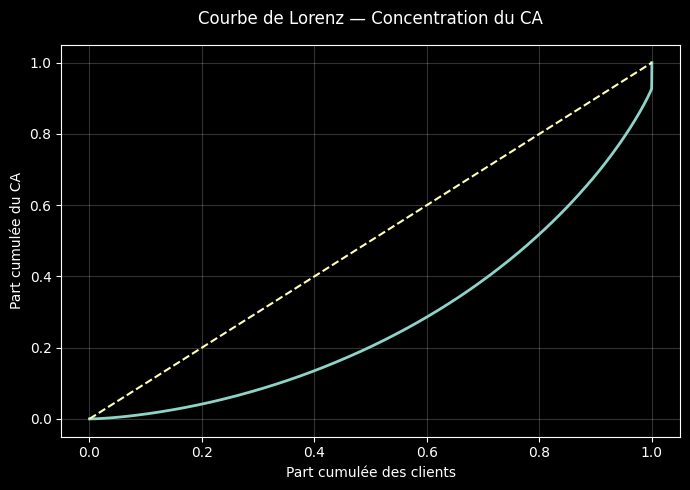

```python
# Graphique Courbe de Lorenz

plt.style.use("dark_background")

# Tri croissant pour Lorenz
ca_sorted_asc = np.sort(ca_client["ca_total"].values)

# Cumuls
ca_cumsum = np.cumsum(ca_sorted_asc)
ca_cumsum = np.insert(ca_cumsum, 0, 0)
ca_cumsum = ca_cumsum / ca_cumsum[-1]

clients_cum = np.linspace(0, 1, len(ca_cumsum))

fig, ax = plt.subplots(figsize=(7,5))

ax.plot(clients_cum, ca_cumsum, linewidth=2)
ax.plot([0,1], [0,1], linestyle="--")

ax.set_title("Courbe de Lorenz — Concentration du CA", pad=15)
ax.set_xlabel("Part cumulée des clients")
ax.set_ylabel("Part cumulée du CA")
ax.grid(alpha=0.2)

plt.tight_layout()
plt.show()
```

📈 **Courbe de Lorenz — Répartition du chiffre d’affaires**

La courbe de Lorenz permet de visualiser comment le chiffre d’affaires est réparti entre les clients.

- 📊 La diagonale représente une répartition parfaitement équitable.
- 📉 Plus la courbe s’éloigne de cette diagonale, plus le CA est concentré.
- 🏆 Une forte courbure signifie qu’un petit nombre de clients génère une grande partie du CA.

👉 **Lecture simplifiée :**  
Si 20 % des clients génèrent 80 % du chiffre d’affaires, la courbe sera très éloignée de la diagonale (effet Pareto marqué).

✅ **Pourquoi c’est important ?**  
Cela permet d’identifier le niveau de dépendance économique à un petit groupe de clients clés.

```python
# Coefficient de Gini

# Formule Gini
n = len(ca_sorted_asc)
index = np.arange(1, n+1)

gini = (2 * np.sum(index * ca_sorted_asc)) / (n * np.sum(ca_sorted_asc)) - (n + 1) / n

print(f"Coefficient de Gini : {gini:.3f}")

if gini < 0.3:
    print("➡️ Concentration faible")
elif gini < 0.5:
    print("➡️ Concentration modérée")
else:
    print("➡️ Concentration forte (effet Pareto marqué)")
```

```
Coefficient de Gini : 0.442
➡️ Concentration modérée
```

📊 **Coefficient de Gini — Mesure de concentration**

Le coefficient de Gini mesure numériquement le niveau d’inégalité dans la répartition du chiffre d’affaires.

- 🔵 Valeur entre **0 et 1**.
- 0 = répartition parfaitement équitable.
- 1 = concentration totale sur un seul client.

👉 **Interprétation rapide :**  
• Gini < 0,30 → concentration faible  
• 0,30 – 0,50 → concentration modérée  
• > 0,50 → forte concentration (effet Pareto important)

⚠️ **Attention stratégique :**  
Une forte concentration peut être très rentable, mais elle augmente aussi le risque en cas de perte d’un client majeur.

📈 **Étape 6.2 — Concentration du CA & Courbe de Lorenz**

Cette analyse permet d’évaluer si le chiffre d’affaires est réparti de manière équilibrée entre les clients ou s’il dépend fortement d’un petit groupe.

- 🥇 Les **10 %** meilleurs clients génèrent environ **31,6 %** du CA.
- 🥈 Les **20 %** meilleurs clients génèrent environ **48,1 %** du CA.
- 📊 Le **coefficient de Gini = 0,44**, indiquant une concentration modérée.

👉 **Comment lire la courbe de Lorenz ?**  
Si la courbe suit la diagonale, le chiffre d’affaires est réparti équitablement.  
Plus elle s’en éloigne, plus le CA est concentré sur un petit nombre de clients.

✅ **Conclusion stratégique :**  
La concentration est **réelle mais non extrême**. L’entreprise ne dépend pas d’un micro-segment ultra dominant, mais près de la moitié du CA repose tout de même sur 20 % des clients. Cela suggère un portefeuille relativement équilibré avec un noyau de clients clés.

## Étape 7 — Clients atypiques (BtoB)

### Étape 7.1 — Identification des clients atypiques

```python
# Objectif : repérer des clients présentant des volumes/CA très élevés
# souvent associés à des achats d'entreprise (BtoB) pouvant biaiser
# les analyses statistiques
CLIENT_COL = "client_id"

clients_kpi = (
    dataset_final
    .groupby(CLIENT_COL)
    .agg(
        nb_transactions=("id_prod", "count"),
        quantite_totale=("quantity", "sum") if "quantity" in dataset_final.columns else ("id_prod", "count"),
        ca_total=("price", "sum")
    )
    .reset_index()
)

display(clients_kpi.sort_values("ca_total", ascending=False).head(10))
```

|  | client_id | nb_transactions | quantite_totale | ca_total |
| --- | --- | --- | --- | --- |
| 677 | c_1609 | 25586 | 25586 | 326039.89 |
| 4388 | c_4958 | 5222 | 5222 | 290227.03 |
| 6337 | c_6714 | 9199 | 9199 | 153918.60 |
| 2724 | c_3454 | 6793 | 6793 | 114110.57 |
| 634 | c_1570 | 370 | 370 | 5285.82 |
| 2513 | c_3263 | 403 | 403 | 5276.87 |
| 1268 | c_2140 | 405 | 405 | 5260.18 |
| 2108 | c_2899 | 105 | 105 | 5214.05 |
| 7006 | c_7319 | 371 | 371 | 5155.77 |
| 7715 | c_7959 | 372 | 372 | 5135.75 |

```python
# Détection des outliers via IQR (robuste)
# Critères : CA total et/ou nb_transactions très élevés
def iqr_bounds(series, k=1.5):
    q1 = series.quantile(0.25)
    q3 = series.quantile(0.75)
    iqr = q3 - q1
    return q1 - k * iqr, q3 + k * iqr

low_ca, high_ca = iqr_bounds(clients_kpi["ca_total"], k=1.5)
low_tx, high_tx = iqr_bounds(clients_kpi["nb_transactions"], k=1.5)

clients_kpi["atypique_ca"] = clients_kpi["ca_total"] > high_ca
clients_kpi["atypique_tx"] = clients_kpi["nb_transactions"] > high_tx

clients_atypiques = clients_kpi[clients_kpi["atypique_ca"] | clients_kpi["atypique_tx"]].copy()

print("Seuil CA (IQR) :", round(high_ca, 2))
print("Seuil transactions (IQR) :", int(high_tx))
print("Nombre de clients atypiques détectés :", len(clients_atypiques))

display(clients_atypiques.sort_values("ca_total", ascending=False).head(20))
```

```
Seuil CA (IQR) : 3650.2
Seuil transactions (IQR) : 200
Nombre de clients atypiques détectés : 660
```

|  | client_id | nb_transactions | quantite_totale | ca_total | atypique_ca | atypique_tx |
| --- | --- | --- | --- | --- | --- | --- |
| 677 | c_1609 | 25586 | 25586 | 326039.89 | True | True |
| 4388 | c_4958 | 5222 | 5222 | 290227.03 | True | True |
| 6337 | c_6714 | 9199 | 9199 | 153918.60 | True | True |
| 2724 | c_3454 | 6793 | 6793 | 114110.57 | True | True |
| 634 | c_1570 | 370 | 370 | 5285.82 | True | True |
| 2513 | c_3263 | 403 | 403 | 5276.87 | True | True |
| 1268 | c_2140 | 405 | 405 | 5260.18 | True | True |
| 2108 | c_2899 | 105 | 105 | 5214.05 | True | False |
| 7006 | c_7319 | 371 | 371 | 5155.77 | True | True |
| 7715 | c_7959 | 372 | 372 | 5135.75 | True | True |
| 470 | c_1422 | 379 | 379 | 5131.36 | True | True |
| 7120 | c_7421 | 381 | 381 | 5097.18 | True | True |
| 7791 | c_8026 | 376 | 376 | 5082.58 | True | True |
| 1673 | c_2505 | 366 | 366 | 5059.35 | True | True |
| 973 | c_1876 | 358 | 358 | 5026.60 | True | True |
| 3870 | c_4491 | 328 | 328 | 5025.05 | True | True |
| 4726 | c_5263 | 98 | 98 | 5006.85 | True | False |
| 1772 | c_2595 | 398 | 398 | 4959.66 | True | True |
| 8195 | c_8392 | 369 | 369 | 4934.01 | True | True |
| 8469 | c_880 | 365 | 365 | 4897.19 | True | True |

🔎 **Étape 7.1 — Identification des clients atypiques**

L’objectif est de repérer les clients dont le comportement d’achat est **très différent de la majorité** (volumes ou chiffre d’affaires exceptionnellement élevés). Ces profils peuvent fausser les analyses en “tirant” les résultats vers le haut.

- 📦 Calcul d’indicateurs par client : **nombre de transactions**, **quantité totale** (si disponible) et **CA total**.
- 🧮 Détection des valeurs extrêmes via une méthode robuste : **IQR** (InterQuartile Range).
- ✅ Un client est considéré atypique s’il dépasse le seuil IQR sur le **CA** et/ou le **nombre de transactions**.

🧾 **Résultat :**  
Les clients atypiques identifiés représentent un petit groupe avec des volumes/CA très élevés. Dans ce dataset, **660** clients ont été détectés comme atypiques (selon les seuils IQR calculés).

### Étape 7.2 — Justification de l’exclusion pour l’analyse statistique

```python
# Impact sur le CA et le volume
ca_total_global = dataset_final["price"].sum()
ca_atypiques = dataset_final[dataset_final[CLIENT_COL].isin(clients_atypiques[CLIENT_COL])]["price"].sum()

part_ca_atypiques = ca_atypiques / ca_total_global * 100

print(f"CA total global : {ca_total_global:,.0f} €".replace(",", " "))
print(f"CA des clients atypiques : {ca_atypiques:,.0f} €".replace(",", " "))
print(f"Part du CA portée par les atypiques : {part_ca_atypiques:.2f} %")

# Nombre de transactions concernées
tx_global = len(dataset_final)
tx_atypiques = dataset_final[dataset_final[CLIENT_COL].isin(clients_atypiques[CLIENT_COL])].shape[0]
print(f"Transactions globales : {tx_global:,}".replace(",", " "))
print(f"Transactions atypiques : {tx_atypiques:,}".replace(",", " "))
print(f"Part des transactions atypiques : {tx_atypiques/tx_global*100:.2f} %")
```

```
CA total global : 12 027 663 €
CA des clients atypiques : 3 168 402 €
Part du CA portée par les atypiques : 26.34 %
Transactions globales : 687 534
Transactions atypiques : 209 076
Part des transactions atypiques : 30.41 %
```

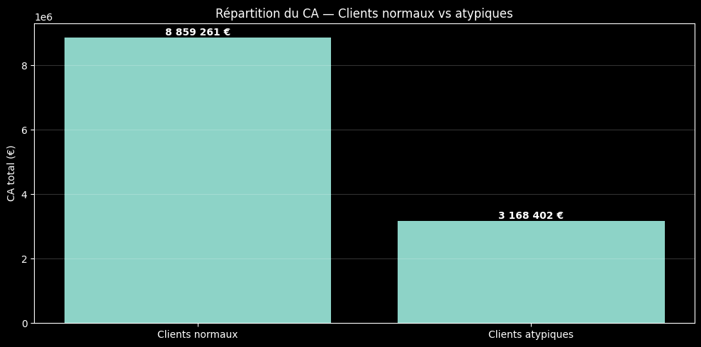

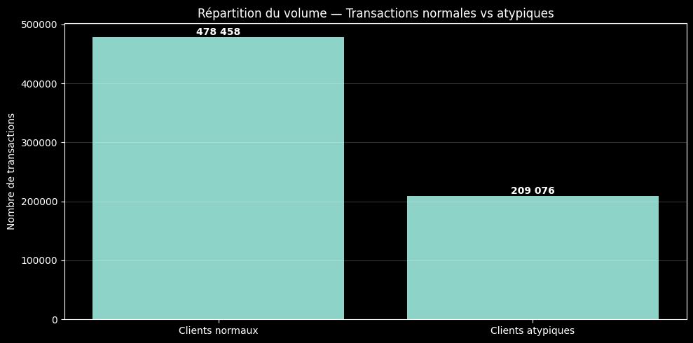

```python
# Graphique : comparaison Atypiques vs Normaux (parts)

# Sécurise la variable même si tu relances la cellule seule
ids_atypiques = set(clients_atypiques[CLIENT_COL].unique())
ca_total_global = dataset_final["price"].sum()
tx_total_global = len(dataset_final)

mask_atyp = dataset_final[CLIENT_COL].isin(ids_atypiques)

ca_atyp = dataset_final.loc[mask_atyp, "price"].sum()
tx_atyp = mask_atyp.sum()

ca_norm = ca_total_global - ca_atyp
tx_norm = tx_total_global - tx_atyp

labels = ["Clients normaux", "Clients atypiques"]
ca_vals = [ca_norm, ca_atyp]
tx_vals = [tx_norm, tx_atyp]

plt.style.use("dark_background")
fig, ax = plt.subplots(figsize=(10, 5))

x = range(len(labels))
ax.bar(x, ca_vals)
ax.set_xticks(list(x))
ax.set_xticklabels(labels)
ax.set_title("Répartition du CA — Clients normaux vs atypiques")
ax.set_ylabel("CA total (€)")
ax.grid(axis="y", alpha=0.2)

for i, v in enumerate(ca_vals):
    ax.text(i, v, f"{v:,.0f} €".replace(",", " "), ha="center", va="bottom", fontweight="bold")

plt.tight_layout()
plt.show()

plt.style.use("dark_background")
fig, ax = plt.subplots(figsize=(10, 5))

ax.bar(x, tx_vals)
ax.set_xticks(list(x))
ax.set_xticklabels(labels)
ax.set_title("Répartition du volume — Transactions normales vs atypiques")
ax.set_ylabel("Nombre de transactions")
ax.grid(axis="y", alpha=0.2)

for i, v in enumerate(tx_vals):
    ax.text(i, v, f"{int(v):,}".replace(",", " "), ha="center", va="bottom", fontweight="bold")

plt.tight_layout()
plt.show()
```

📊 **Étape 7.2 — Justification de l’exclusion pour l’analyse statistique**

Avant de lancer les corrélations et les tests statistiques, on mesure l’impact réel des clients atypiques sur l’activité. L’idée est simple : si quelques clients pèsent très lourd, ils peuvent **brouiller la lecture** des comportements “moyens”.

- 💰 **CA global** : **12 027 663 €**
- 🏢 **CA des clients atypiques** : **3 168 402 €** (≈ **26,34 %** du CA)
- 🧾 **Transactions globales** : **687 534**
- 🏢 **Transactions atypiques** : **209 076** (≈ **30,41 %** du volume)

👉 **En clair :**  
Même s’ils sont minoritaires, les clients atypiques représentent une part importante du CA et du volume. Les analyses statistiques risquent donc de refléter surtout **leur** comportement, au détriment du “client moyen”.

### Étape 7.3 — Nouveau dataset sans BtoB

```python
# Supprimer les clients atypiques pour ne pas biaiser les tests stats
ids_atypiques = set(clients_atypiques[CLIENT_COL].unique())

# Sans BtoB = on exclut les clients atypiques
df_sans_btob = dataset_final[~dataset_final[CLIENT_COL].isin(ids_atypiques)].copy()

print("Dataset original :", dataset_final.shape)
print("Dataset sans BtoB :", df_sans_btob.shape)
print("Clients supprimés :", len(ids_atypiques))

# Vérification
assert df_sans_btob[CLIENT_COL].isin(ids_atypiques).sum() == 0
```

```
Dataset original : (687534, 8)
Dataset sans BtoB : (478458, 8)
Clients supprimés : 660
```

✅ **Étape 7.3 — Création d’un dataset “sans BtoB”**

Pour obtenir des analyses statistiques plus représentatives du grand public, on crée un nouveau dataset en **mettant de côté** les clients atypiques.

- 🧹 Exclusion des clients détectés comme atypiques (IQR) du dataset principal.
- 📦 Création d’un dataset filtré : **df_sans_btob**.
- 🔬 Ce dataset sera utilisé pour l’étape suivante : **corrélations** et **tests statistiques**.

🧾 **Contrôle :**  
Dataset original : **687 534** lignes  
Dataset “sans BtoB” : **478 458** lignes  
Clients mis de côté : **660**

🎯 **Conclusion :**  
En clair, on a identifié un petit groupe de clients qui achètent “en très grandes quantités”. Ces comportements sont **souvent compatibles avec du BtoB** (achats d’entreprise, achats groupés, revendeurs), même si le dataset ne permet pas de le prouver à 100 % faute d’un champ “type de client”.  
Pour éviter que ces profils atypiques ne **faussent** les corrélations et tests statistiques, on les a donc **isolés** et on réalise les analyses statistiques sur un dataset plus représentatif du comportement “grand public”.  
✅ Résultat : des conclusions plus fiables, plus lisibles et plus utiles pour prendre des décisions marketing.

## Étape 8 — Corrélations et tests statistiques

### Étape 8.1 — Corrélations exploratoires

```python
# Objectif : analyser les relations entre les variables quantitatives clients
print("Analyse des corrélations\n")

# Agrégation client
client_stats = df_sans_btob.groupby("client_id").agg(
    nb_transactions=("price", "size"),
    ca_total=("price", "sum"),
    panier_moyen=("price", "mean")
).reset_index()

display(client_stats.head())

print(f"Nombre de clients analysés : {len(client_stats)}")
```

```
Analyse des corrélations
```

|  | client_id | nb_transactions | ca_total | panier_moyen |
| --- | --- | --- | --- | --- |
| 0 | c_1 | 43 | 629.02 | 14.628372 |
| 1 | c_10 | 58 | 1353.60 | 23.337931 |
| 2 | c_100 | 8 | 254.85 | 31.856250 |
| 3 | c_1000 | 126 | 2291.88 | 18.189524 |
| 4 | c_1001 | 103 | 1823.85 | 17.707282 |

```
Nombre de clients analysés : 7940
```

```python
# Calcul de la matrice de corrélation
corr_matrix = client_stats[["nb_transactions", "ca_total", "panier_moyen"]].corr()

display(corr_matrix)
```

|  | nb_transactions | ca_total | panier_moyen |
| --- | --- | --- | --- |
| nb_transactions | 1.000000 | 0.736681 | -0.354618 |
| ca_total | 0.736681 | 1.000000 | 0.216783 |
| panier_moyen | -0.354618 | 0.216783 | 1.000000 |

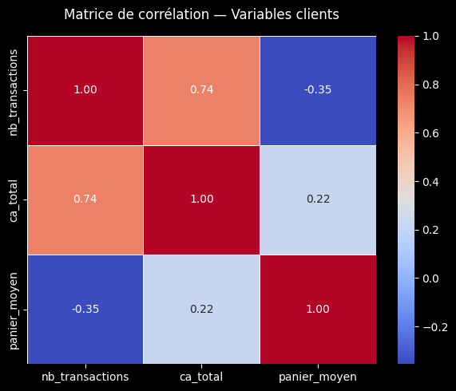

```python
# Graphique Heatmap des corrélations
plt.style.use("dark_background")

plt.figure(figsize=(6,5))

sns.heatmap(
    corr_matrix,
    annot=True,
    cmap="coolwarm",
    fmt=".2f",
    linewidths=0.5
)

plt.title("Matrice de corrélation — Variables clients", pad=15)
plt.tight_layout()
plt.show()
```

🧠 **Interprétation rapide des corrélations**

Lecture de la matrice de corrélation obtenue sur le dataset **“sans BtoB”** (clients atypiques exclus).

🔢 **Valeurs observées**

- 🔁 **Transactions ↔ CA total** : **0,737**
- 🧺 **Panier moyen ↔ CA total** : **0,217**
- 🧾 **Transactions ↔ Panier moyen** : **-0,355**

👉 **En clair**

- **Plus un client achète souvent, plus il génère de CA** : la relation est **forte** entre **transactions** et **CA total** (**0,737**).
- Le **panier moyen** a un lien **faible** avec le CA total (**0,217**) : augmenter le panier moyen seul ne suffit pas à expliquer une forte hausse du CA.
- La relation **négative** entre transactions et panier moyen (**-0,355**) suggère que les clients qui achètent très souvent ont tendance à faire des achats plus petits.

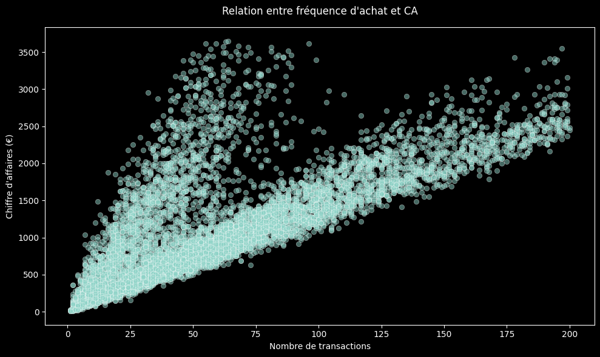

```python
# Graphique visualisation fréquence vs CA
plt.figure(figsize=(10,6))

sns.scatterplot(
    data=client_stats,
    x="nb_transactions",
    y="ca_total",
    alpha=0.5
)

plt.title("Relation entre fréquence d'achat et CA", pad=15)
plt.xlabel("Nombre de transactions")
plt.ylabel("Chiffre d'affaires (€)")
plt.tight_layout()
plt.show()
```

📈 **Étape 8.1 — Corrélations exploratoires (dataset “sans BtoB”)**

Cette étape explore les relations entre les indicateurs clients afin d’identifier les facteurs qui influencent le chiffre d’affaires. L’analyse est réalisée sur le dataset **“sans BtoB”** (clients atypiques exclus) pour éviter les biais liés aux très gros volumes.

✅ **Périmètre analysé :**

- **7 940** clients analysés (dataset filtré)
- Variables : **nombre de transactions**, **CA total**, **panier moyen**

🔢 **Résultats clés (corrélations)**

- 🔁 **Transactions ↔ CA total** : **≈ 0,74** → relation **forte** : plus un client achète souvent, plus il génère de CA.
- 🧺 **Panier moyen ↔ CA total** : **≈ 0,22** → relation **faible** : augmenter le panier moyen seul explique peu la hausse du CA.
- 🧾 **Transactions ↔ Panier moyen** : **≈ -0,35** → relation **modérée négative** : les clients très fréquents ont tendance à avoir un panier moyen plus faible.

👉 **En clair :**  
Le chiffre d’affaires est principalement “porté” par la **fréquence d’achat** (fidélisation / récurrence). Le panier moyen joue un rôle plus limité à ce stade, et il existe un effet : certains clients achètent souvent, mais sur des paniers plus petits.

✅ **Conclusion :**  
Les priorités marketing devraient viser en premier lieu :

- 🔁 **Augmenter la récurrence** (relances, e-mailing, CRM, reminders)
- ⭐ **Renforcer la fidélisation** (programme de fidélité, avantages, segmentation)
- 🧺 Puis en complément : **optimiser le panier moyen** (bundles, cross-sell, recommandations)

### Étape 8.2.1 — χ² (catégories)

```python
# Check colonnes — aperçu complet du dataset "sans BtoB"
df = df_sans_btob.copy()

print("Shape :", df.shape)
display(pd.DataFrame({
    "column": df.columns,
    "dtype": [str(df[c].dtype) for c in df.columns],
    "missing_%": [(df[c].isna().mean()*100) for c in df.columns],
    "n_unique": [df[c].nunique(dropna=True) for c in df.columns],
}).sort_values("missing_%", ascending=False))
```

```
Shape : (478458, 8)
```

|  | column | dtype | missing_% | n_unique |
| --- | --- | --- | --- | --- |
| 0 | id_prod | string | 0.0 | 3226 |
| 1 | date | datetime64[ns] | 0.0 | 478344 |
| 2 | session_id | string | 0.0 | 253945 |
| 3 | client_id | string | 0.0 | 7940 |
| 4 | price | float64 | 0.0 | 1431 |
| 5 | categ | Int64 | 0.0 | 3 |
| 6 | sex | string | 0.0 | 2 |
| 7 | birth | Int64 | 0.0 | 76 |

```python
# Colonnes catégorielles candidates (pour χ²)
df = df_sans_btob.copy()

# candidates: object / category
cat_cols = []

for c in df.columns:
    if df[c].dtype == "object" or str(df[c].dtype) == "category":
        cat_cols.append(c)
    else:
        # ex: int avec peu de modalités (0/1/2/3...)
        if pd.api.types.is_integer_dtype(df[c]) and df[c].nunique() <= 20:
            cat_cols.append(c)

print("Colonnes catégorielles candidates :", cat_cols)

# Aperçu des modalités pour les + pertinentes (limité)
for c in cat_cols[:10]:
    print("\n---", c, "---")
    display(df[c].value_counts().head(10))
```

```
Colonnes catégorielles candidates : ['categ']

--- categ ---
```

```
categ
0    265577
1    182571
2     30310
Name: count, dtype: Int64
```

```python
# Focus sur la variable "categ"
if "categ" in df.columns:
    print("Modalités de categ :", df["categ"].unique())
    display(df["categ"].value_counts(normalize=True).mul(100).round(2).rename("percent"))
else:
    print("⚠️ La colonne 'categ' n'existe pas dans df_sans_btob.")
```

```
Modalités de categ : <IntegerArray>
[0, 1, 2]
Length: 3, dtype: Int64
```

```
categ
0    55.51
1    38.16
2     6.33
Name: percent, dtype: Float64
```

```python
# Base — Construire l'âge et un dataset client pour les tests
# Objectif : préparer les variables Age, CA total, fréquence et panier moyen
df = df_sans_btob.copy()

# âge au moment de l'achat (année transaction - année naissance)
df["age"] = df["date"].dt.year - df["birth"]

# sécurité : on garde des âges plausibles (à ajuster si besoin)
df = df[(df["age"] >= 10) & (df["age"] <= 100)].copy()

# dataset client
client_stats = (
    df.groupby("client_id")
      .agg(
          age=("age", "median"),             # âge "représentatif" du client
          nb_transactions=("price", "size"),
          ca_total=("price", "sum"),
          panier_moyen=("price", "mean"),
          sex=("sex", "first")               # 1 valeur par client
      )
      .reset_index()
)

display(client_stats.head())
print("Clients analysés :", len(client_stats))
```

|  | client_id | age | nb_transactions | ca_total | panier_moyen | sex |
| --- | --- | --- | --- | --- | --- | --- |
| 0 | c_1 | 66.0 | 43 | 629.02 | 14.628372 | m |
| 1 | c_10 | 66.0 | 58 | 1353.60 | 23.337931 | m |
| 2 | c_100 | 29.0 | 8 | 254.85 | 31.856250 | m |
| 3 | c_1000 | 56.0 | 126 | 2291.88 | 18.189524 | f |
| 4 | c_1001 | 40.0 | 103 | 1823.85 | 17.707282 | m |

```
Clients analysés : 7940
```

```
χ²(sex vs categ) = 15.28 | ddl=2 | p-value=0.0005
```

| categ sex | 0 | 1 | 2 |
| --- | --- | --- | --- |
| f | 138578 | 96282 | 15763 |
| m | 126999 | 86289 | 14547 |

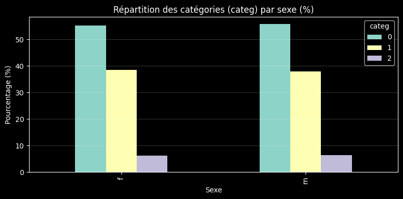

```python
# Test du χ² : Sexe vs Catégorie produit (categ)
# Objectif : vérifier s'il existe une dépendance entre le sexe du client (f/m)
# et la catégorie de produits achetés (categ)
from scipy.stats import chi2_contingency

cont = pd.crosstab(df["sex"], df["categ"])
chi2, p, dof, expected = chi2_contingency(cont)

print(f"χ²(sex vs categ) = {chi2:.2f} | ddl={dof} | p-value={p:.4f}")
display(cont)

# Graph % par sexe
pct = cont.div(cont.sum(axis=1), axis=0) * 100

plt.style.use("dark_background")
fig, ax = plt.subplots(figsize=(8,4))
pct.plot(kind="bar", ax=ax)
ax.set_title("Répartition des catégories (categ) par sexe (%)")
ax.set_xlabel("Sexe")
ax.set_ylabel("Pourcentage (%)")
ax.grid(axis="y", alpha=0.2)
plt.tight_layout()
plt.show()
```

```
χ²(age_group vs categ) = 184175.60 | ddl=10 | p-value=0.0000
```

| categ age_group | 0 | 1 | 2 |
| --- | --- | --- | --- |
| 10-19 | 4509 | 8065 | 7746 |
| 20-29 | 10832 | 19015 | 18528 |
| 30-39 | 80969 | 28135 | 1929 |
| 40-49 | 93038 | 31820 | 581 |
| 50-59 | 37910 | 45290 | 706 |
| 60+ | 38319 | 50246 | 820 |

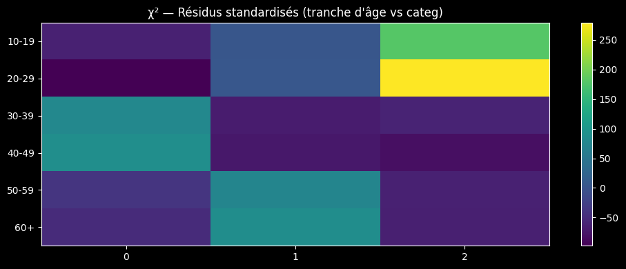

```python
# χ² — Tranche d'âge vs catégorie de livres achetés (categ)
# Objectif : vérifier si les catégories varient selon l'âge
from scipy.stats import chi2_contingency

# Tranches d’âge (modifiables)
bins = [10, 20, 30, 40, 50, 60, 100]
labels = ["10-19", "20-29", "30-39", "40-49", "50-59", "60+"]

df["age_group"] = pd.cut(df["age"], bins=bins, labels=labels, right=False)

cont_age = pd.crosstab(df["age_group"], df["categ"])
chi2, p, dof, expected = chi2_contingency(cont_age)

print(f"χ²(age_group vs categ) = {chi2:.2f} | ddl={dof} | p-value={p:.4f}")
display(cont_age)

# Heatmap des résidus standardisés
expected_df = pd.DataFrame(expected, index=cont_age.index, columns=cont_age.columns)
residuals = (cont_age - expected_df) / np.sqrt(expected_df)

plt.style.use("dark_background")
fig, ax = plt.subplots(figsize=(10, 4))
im = ax.imshow(residuals.values, aspect="auto")
ax.set_title("χ² — Résidus standardisés (tranche d'âge vs categ)")
ax.set_xticks(range(len(residuals.columns)))
ax.set_xticklabels(residuals.columns)
ax.set_yticks(range(len(residuals.index)))
ax.set_yticklabels(residuals.index)
plt.colorbar(im, ax=ax)
plt.tight_layout()
plt.show()
```

🧩 **Étape 8.2.1 — Test du χ² (variables catégorielles)**

Le test du **χ²** permet de vérifier si deux variables **catégorielles** sont indépendantes ou non. Ici, l’objectif est d’évaluer si la **catégorie de livres achetés (categ)** varie en fonction : du **sexe** du client, et de sa **tranche d’âge**.

🔎 **Rappel méthode (χ²) :**

- On construit une **table de contingence** (comptages) entre deux catégories.
- Le χ² compare les effectifs **observés** vs **attendus** si les variables étaient indépendantes.
- Si **p-value < 0,05**, on conclut à une **dépendance** (répartition non aléatoire).

📌 **Résultats obtenus**

- 👤 **Sexe ↔ categorie (categ)** : **χ² = 15,28** | ddl = 2 | **p-value = 0,0005** → dépendance **significative** (répartition différente selon f/m).
- 🎂 **Tranche d’âge ↔ categorie (categ)** : **χ² = 184 175,60** | ddl = 10 | **p-value ≈ 0,0000** → dépendance **très significative** (répartition fortement différente selon l’âge).

📊 **Comment lire les graphiques ?**

**1) Bar chart en % (categ par sexe)** :  
Il compare la **structure** des catégories entre **f** et **m** en neutralisant la taille d’échantillon (on compare des proportions, pas des volumes).

**2) Heatmap des résidus standardisés (tranche d’âge vs categ)** :  
Elle montre **où** se situent les plus gros écarts entre “observé” et “attendu”.

- Résidus **positifs** : catégorie **sur-représentée** dans la tranche d’âge.
- Résidus **négatifs** : catégorie **sous-représentée** dans la tranche d’âge.

✅ **Conclusion (interprétation simple) :**  
La répartition des catégories de livres achetés (**categ**) **varie significativement** selon le **sexe** et surtout selon la **tranche d’âge**. Cela confirme des **différences de préférences d’achat** entre profils, ce qui justifie des actions de **segmentation** (ex : recommandations produits ou campagnes ciblées par âge).

### 8.2.2 — Vérification des hypothèses (Smirnov/KS, QQ-plot, histogramme, Levene)

```
KS normality — panier_moyen (global) : D=0.271 | p=0
```

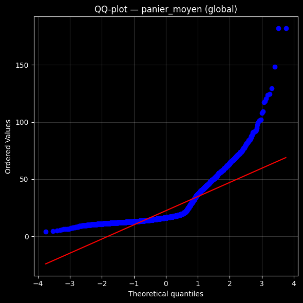

```python
from scipy.stats import kstest, probplot, norm, levene

plt.style.use("dark_background")

def ks_normality_report(x, label):
    x = np.asarray(x)
    x = x[~np.isnan(x)]
    z = (x - x.mean()) / x.std(ddof=1)
    stat, p = kstest(z, 'norm')
    print(f"KS normality — {label} : D={stat:.3f} | p={p:.3g}")
    return stat, p

# 1) KS sur la variable globale
ks_normality_report(client_stats["panier_moyen"], "panier_moyen (global)")

# 2) QQ-plot global (visuel “cloche”)
fig, ax = plt.subplots(figsize=(6,6))
probplot(client_stats["panier_moyen"].dropna(), dist="norm", plot=ax)
ax.set_title("QQ-plot — panier_moyen (global)")
ax.grid(alpha=0.2)
plt.tight_layout()
plt.show()
```

```python
# age_group
bins = [10, 20, 30, 40, 50, 60, 100]
labels = ["10-19", "20-29", "30-39", "40-49", "50-59", "60+"]
client_stats["age_group"] = pd.cut(client_stats["age"], bins=bins, labels=labels, right=False)

# groups + observed=True
groups = [g["panier_moyen"].dropna().values
          for _, g in client_stats.groupby("age_group", observed=True)
          if len(g) > 0]

lev_stat, lev_p = levene(*groups, center="median")
print(f"Levene (variances) — panier_moyen ~ age_group : stat={lev_stat:.2f} | p={lev_p:.3g}")
```

```
Levene (variances) — panier_moyen ~ age_group : stat=707.96 | p=0
```

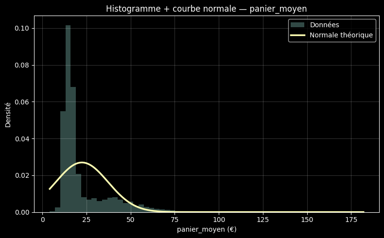

```python
from scipy.stats import norm

plt.style.use("dark_background")

x = client_stats["panier_moyen"].dropna().values

fig, ax = plt.subplots(figsize=(8,5))
ax.hist(x, bins=60, density=True, alpha=0.35, label="Données")

mu, sigma = x.mean(), x.std(ddof=1)
xx = np.linspace(x.min(), x.max(), 400)
ax.plot(xx, norm.pdf(xx, mu, sigma), linewidth=2.5, label="Normale théorique")

ax.set_title("Histogramme + courbe normale — panier_moyen")
ax.set_xlabel("panier_moyen (€)")
ax.set_ylabel("Densité")
ax.grid(alpha=0.2)
ax.legend()
plt.tight_layout()
plt.show()
```

🧪 **Étape 8.2.2.a — Vérification des hypothèses (avant ANOVA)**

Avant d’appliquer une **ANOVA**, on vérifie deux points classiques : **la normalité** de la variable étudiée (ici **panier_moyen**) et **l’égalité des variances** entre les groupes (tranches d’âge). Ces contrôles servent principalement à ANOVA ; pour Pearson/Spearman, ils permettent surtout de justifier Spearman comme approche robuste.

🧠 **Ce que font les méthodes :**

- **Kolmogorov–Smirnov (KS / Smirnov)** : teste si une variable suit une **loi normale** (après standardisation).
- **QQ-plot** : comparaison visuelle à la normale (si les points suivent la diagonale → proche d’une normale).
- **Histogramme + courbe normale** : lecture “cloche” intuitive (forme globale + asymétrie).
- **Levene** : teste si les **variances** sont comparables entre groupes (pré-requis de l’ANOVA classique).

📊 **Comment lire les graphiques “normalité” ?**  
**1) QQ-plot (panier_moyen)** :  
Si les points suivent la diagonale, la distribution est proche de la normale. Des écarts forts (surtout en fin de queue) indiquent une **asymétrie** et/ou des **valeurs extrêmes**.  
**2) Histogramme + courbe normale** :  
Permet de voir rapidement si la forme ressemble à une “cloche”. Une queue longue à droite (souvent le cas en montants d’achat) indique une distribution **non normale** (asymétrie positive).

📌 **Résultats observés**

- 🧾 **Smirnov (KS) sur panier_moyen** : **D = 0,271** | **p ≈ 0** → la normalité est **rejetée** (test très sensible avec un grand volume de données).
- ⚖️ **Levene (variances) entre tranches d’âge** : **stat = 707,96** | **p ≈ 0** → variances **différentes** entre groupes (hétéroscédasticité).

✅ **Conclusion (interprétation simple) :**  
Les contrôles indiquent que **panier_moyen** n’est pas strictement normal et que les variances diffèrent selon l’âge.

👉 **Pour l’ANOVA** : malgré ces écarts, l’**ANOVA** reste souvent utilisée en pratique (relative robustesse avec un grand échantillon).

👉 **Pour les corrélations (Pearson/Spearman)** : ces résultats de “non-normalité” renforcent l’intérêt de présenter **Spearman** (corrélation monotone, plus robuste) en complément de **Pearson** (corrélation linéaire). Concrètement, on conserve **Pearson** si la relation paraît globalement **linéaire**, et on s’appuie davantage sur **Spearman** si la relation est **non linéaire** / asymétrique / influencée par des valeurs extrêmes.

### 8.2.3 — ANOVA (panier moyen selon tranche d’âge)

```
ANOVA(panier_moyen ~ age_group) | F = 2145.73 | p-value = 0
```

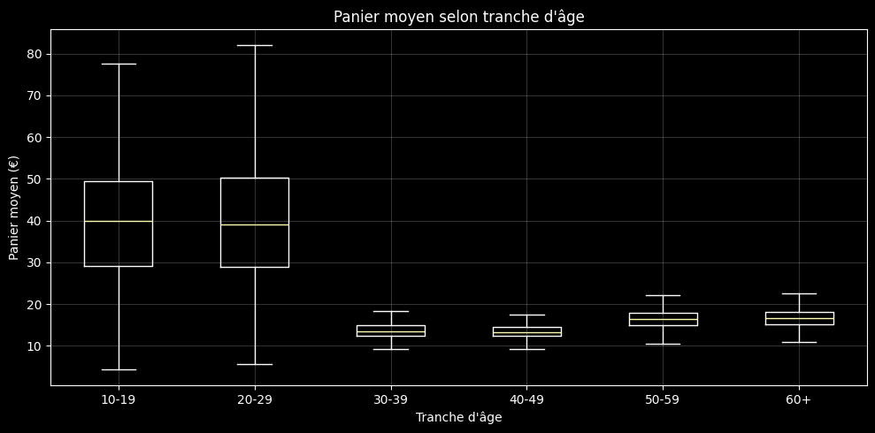

```python
# ANOVA — Panier moyen selon tranche d'âge
# Objectif : comparer la moyenne du panier moyen entre classes d'âge
from scipy.stats import f_oneway

client_stats["age_group"] = pd.cut(client_stats["age"], bins=bins, labels=labels, right=False)

groups = [g["panier_moyen"].values for _, g in client_stats.groupby("age_group", observed=False) if len(g) > 0]
stat, p = f_oneway(*groups)

print(f"ANOVA(panier_moyen ~ age_group) | F = {stat:.2f} | p-value = {p:.4g}")

plt.style.use("dark_background")
fig, ax = plt.subplots(figsize=(10, 5))
order = labels
box_data = [client_stats.loc[client_stats["age_group"] == s, "panier_moyen"].values for s in order]

ax.boxplot(box_data, tick_labels=order, showfliers=False)
ax.set_title("Panier moyen selon tranche d'âge")
ax.set_xlabel("Tranche d'âge")
ax.set_ylabel("Panier moyen (€)")
ax.grid(alpha=0.2)
plt.tight_layout()
plt.show()
```

L’**ANOVA** sert à comparer la **moyenne** d’une variable quantitative entre **plusieurs groupes**. Ici, on compare le **panier moyen** entre différentes **tranches d’âge** (10-19, 20-29, …, 60+), afin d’évaluer si l’âge influence la taille des achats.

🧠 **Ce que fait la méthode :**

- Elle teste si **au moins un groupe** a une moyenne différente des autres.
- Si la **p-value < 0,05**, on conclut à une **différence significative** entre groupes.
- Avec seulement **2 groupes**, on utiliserait plutôt un **t-test**.

📌 **Résultat obtenu**

- **F = 2145,73**
- **p-value ≈ 0** (donc < 0,05)

👉 Cela indique une **différence statistiquement significative** du panier moyen entre les tranches d’âge.

📊 **Comment lire le boxplot ?**  
Le boxplot résume la distribution :

- La **ligne au centre** = médiane (valeur “typique”).
- La **boîte** = 50% des valeurs (entre Q1 et Q3).
- Les **moustaches** = dispersion globale (hors valeurs extrêmes si masquées).

Plus les boîtes sont séparées/éloignées, plus les comportements d’achat diffèrent selon l’âge.

✅ **Conclusion (interprétation simple) :**  
Le test ANOVA confirme que le **panier moyen varie significativement selon la tranche d’âge**. Autrement dit, certains groupes d’âge ont tendance à faire des achats **plus élevés** ou **plus faibles** que d’autres, ce qui peut justifier des stratégies de **segmentation marketing** (offres adaptées par âge).

### 8.2.4 — Pearson & Spearman (âge vs comportements d’achat)

```
Pearson(age vs ca_total)  r = -0.173 | p-value = 1.938e-54
Spearman(age vs ca_total) ρ = -0.164 | p-value = 8.097e-49
```

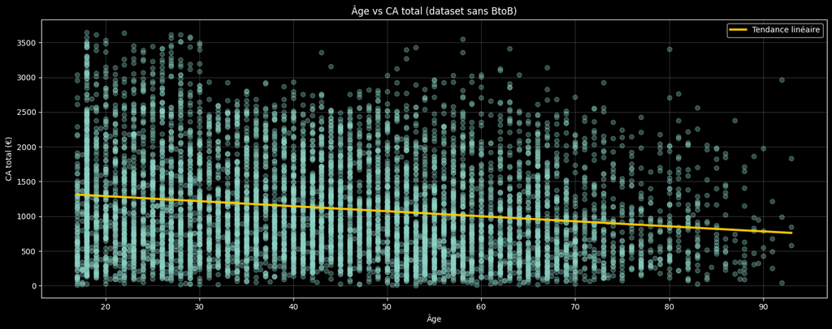

```python
from scipy.stats import pearsonr, spearmanr

# Pearson/Spearman — Âge vs montant total des achats (CA total)
x = client_stats["age"]
y = client_stats["ca_total"]

r_p, p_p = pearsonr(x, y)
r_s, p_s = spearmanr(x, y)

print(f"Pearson(age vs ca_total)  r = {r_p:.3f} | p-value = {p_p:.4g}")
print(f"Spearman(age vs ca_total) ρ = {r_s:.3f} | p-value = {p_s:.4g}")

plt.style.use("dark_background")
fig, ax = plt.subplots(figsize=(15, 6))

# Nuage de points
ax.scatter(x, y, alpha=0.35)

# Droite de tendance (régression linéaire)
m, b = np.polyfit(x, y, 1)                     # slope + intercept
x_line = np.linspace(x.min(), x.max(), 200)
ax.plot(
    x_line,
    m * x_line + b,
    color="#ffcc00",
    linewidth=2.8,
    alpha=0.95,
    label="Tendance linéaire"
)

ax.set_title("Âge vs CA total (dataset sans BtoB)")
ax.set_xlabel("Âge")
ax.set_ylabel("CA total (€)")
ax.grid(alpha=0.2)
ax.legend()
plt.tight_layout()
plt.show()
```

```
Pearson(age vs nb_transactions)  r = 0.126 | p-value = 1.105e-29
Spearman(age vs nb_transactions) ρ = 0.175 | p-value = 1.509e-55
```

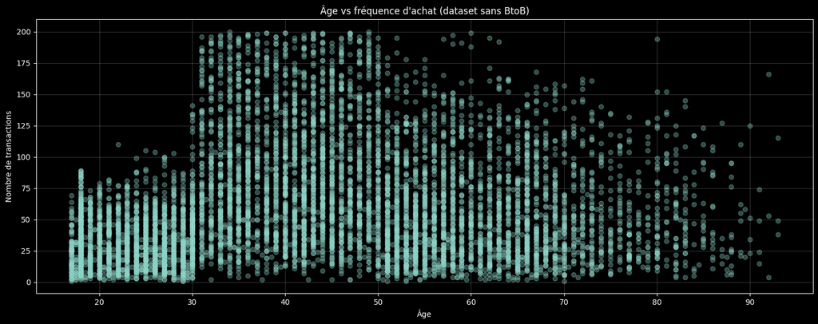

```python
# Pearson/Spearman — Âge vs fréquence d'achat (nb_transactions)
x = client_stats["age"]
y = client_stats["nb_transactions"]

r_p, p_p = pearsonr(x, y)
r_s, p_s = spearmanr(x, y)

print(f"Pearson(age vs nb_transactions)  r = {r_p:.3f} | p-value = {p_p:.4g}")
print(f"Spearman(age vs nb_transactions) ρ = {r_s:.3f} | p-value = {p_s:.4g}")

plt.style.use("dark_background")
fig, ax = plt.subplots(figsize=(15, 6))
ax.scatter(x, y, alpha=0.35)
ax.set_title("Âge vs fréquence d'achat (dataset sans BtoB)")
ax.set_xlabel("Âge")
ax.set_ylabel("Nombre de transactions")
ax.grid(alpha=0.2)
plt.tight_layout()
plt.show()
```

```
Pearson(age vs panier_moyen)  r = -0.525 | p-value = 0
Spearman(age vs panier_moyen) ρ = -0.362 | p-value = 1.067e-244
```

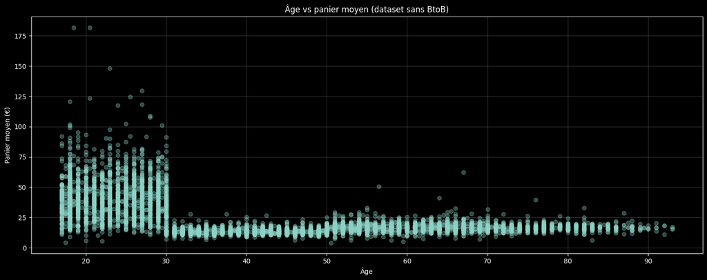

```python
# Pearson/Spearman — Âge vs taille du panier moyen (panier_moyen)
x = client_stats["age"]
y = client_stats["panier_moyen"]

r_p, p_p = pearsonr(x, y)
r_s, p_s = spearmanr(x, y)

print(f"Pearson(age vs panier_moyen)  r = {r_p:.3f} | p-value = {p_p:.4g}")
print(f"Spearman(age vs panier_moyen) ρ = {r_s:.3f} | p-value = {p_s:.4g}")

plt.style.use("dark_background")
fig, ax = plt.subplots(figsize=(15, 6))
ax.scatter(x, y, alpha=0.35)
ax.set_title("Âge vs panier moyen (dataset sans BtoB)")
ax.set_xlabel("Âge")
ax.set_ylabel("Panier moyen (€)")
ax.grid(alpha=0.2)
plt.tight_layout()
plt.show()
```

Les corrélations mesurent la relation entre deux variables **quantitatives**. **Pearson** capte une relation plutôt **linéaire**, tandis que **Spearman** est plus robuste et détecte une relation **monotone** (même si elle n’est pas parfaitement linéaire). L’analyse est réalisée sur le dataset **“sans BtoB”** (clients atypiques exclus).

🧪 **Ce que fait la méthode :**

- On calcule un coefficient **r** (Pearson) ou **ρ** (Spearman) entre **-1** et **+1**.
- On teste la significativité via une **p-value** (p < 0,05 = relation statistiquement significative).
- Plus |r| est grand, plus la relation est forte (attention : **corrélation ≠ causalité**).

🔢 **Résultats observés :**

- 💶 **Âge ↔ CA total** : Pearson r = **-0,173** (p = 1,938e-54) ; Spearman ρ = **-0,164** (p = 8,097e-49).  
  → relation **faible** et **négative** (légère baisse du CA quand l’âge augmente).
- 🔁 **Âge ↔ fréquence d’achat (nb_transactions)** : Pearson r = **0,126** (p = 1,105e-29) ; Spearman ρ = **0,175** (p = 1,509e-55).  
  → relation **faible** et **positive** (légère hausse de fréquence avec l’âge).
- 🧺 **Âge ↔ panier moyen** : Pearson r = **-0,525** (p ≈ 0) ; Spearman ρ = **-0,362** (p = 1,067e-244).  
  → relation **modérée** et **négative** : les clients plus âgés ont tendance à avoir un panier moyen plus faible.

📊 **Comment lire les scatterplots ?**  
Chaque nuage de points représente un client :

- Plus le nuage “monte” avec l’âge, plus la relation est positive ; s’il “descend”, la relation est négative.
- La dispersion montre qu’à âge identique, les comportements peuvent beaucoup varier (profil, goûts, budget, etc.).
- Les p-values très faibles indiquent que les relations observées sont **statistiquement significatives**.

✅ **Conclusion (lecture simple) :**  
L’âge a un effet **faible** sur le **CA total** et la **fréquence** d’achat, mais un effet plus marqué sur la **taille du panier moyen** (tendance à diminuer avec l’âge). Cela suggère que des stratégies “par âge” peuvent être pertinentes surtout pour **adapter les offres** (packs, promotions, recommandations) et optimiser le panier moyen sur certaines tranches d’âge.

### Étape 8.3 — Interprétation des résultats

Les corrélations mesurent la relation entre deux variables **quantitatives**. **Pearson** capte une relation plutôt **linéaire**, tandis que **Spearman** est plus robuste et détecte une relation **monotone** (même si elle n’est pas parfaitement linéaire). L’analyse est réalisée sur le dataset **“sans BtoB”** (clients atypiques exclus).

🧪 **Ce que fait la méthode :**

- On calcule un coefficient **r** (Pearson) ou **ρ** (Spearman) entre **-1** et **+1**.
- On teste la significativité via une **p-value** (p < 0,05 = relation statistiquement significative).
- Plus |r| est grand, plus la relation est forte (attention : **corrélation ≠ causalité**).

🔢 **Résultats observés :**

- 💶 **Âge ↔ CA total** : Pearson r = **-0,173** (p = 1,938e-54) ; Spearman ρ = **-0,164** (p = 8,097e-49).  
  → relation **faible** et **négative** : le CA total tend légèrement à diminuer quand l’âge augmente.
- 🔁 **Âge ↔ fréquence d’achat (nb_transactions)** : Pearson r = **0,126** (p = 1,105e-29) ; Spearman ρ = **0,175** (p = 1,509e-55).  
  → relation **faible** et **positive** : la fréquence d’achat tend légèrement à augmenter avec l’âge.
- 🧺 **Âge ↔ panier moyen** : Pearson r = **-0,525** (p ≈ 0) ; Spearman ρ = **-0,362** (p = 1,067e-244).  
  → relation **modérée** et **négative** : les clients plus âgés ont tendance à avoir un panier moyen plus faible.

📊 **Comment lire les scatterplots ?**  
Chaque nuage de points représente un client :

- Plus le nuage “monte” avec l’âge, plus la relation est positive ; s’il “descend”, la relation est négative.
- La dispersion montre qu’à âge identique, les comportements peuvent beaucoup varier (profil, goûts, budget, etc.).
- Les p-values très faibles indiquent que les relations observées sont **statistiquement significatives**.

✅ **Conclusion (lecture simple) :**  
L’âge a un effet **faible** sur le **CA total** et la **fréquence** d’achat, mais un effet plus marqué sur la **taille du panier moyen** (tendance à diminuer avec l’âge). Cela suggère que des stratégies “par âge” peuvent être pertinentes surtout pour **adapter les offres** (packs, promotions, recommandations) et optimiser le panier moyen sur certaines tranches d’âge.

## Conclusion et recommandations métier

🏁 **Conclusion globale — Synthèse & recommandations métier**

Cette étude analyse les ventes, la performance des produits et le comportement client à partir du dataset nettoyé et consolidé. Pour garantir des analyses statistiques représentatives du “grand public”, un dataset **“sans BtoB”** a été construit en mettant de côté les **clients atypiques** (volumes/CA très élevés) susceptibles de biaiser les résultats.

📦 **1) Périmètre de l’analyse**

- **Transactions**, **produits** et **clients** ont été analysés (EDA + construction du dataset final).
- Analyse temporelle : évolution du **CA**, tendances et variations par période.
- Analyse produits : identification des **tops** et **flops** et répartition du CA.
- Analyse clients : concentration du CA (Lorenz/Gini) + tests statistiques (χ² / ANOVA / corrélations).
- Dataset utilisé pour les tests : **“sans BtoB”** (clients atypiques exclus).

💡 **2) Insights clés (ce qu’on retient)**

- 🧩 **Les catégories de livres (categ) varient selon le sexe et l’âge** : les tests **χ²** sont significatifs, indiquant des préférences différentes entre profils.
- 🧺 **Le panier moyen diminue avec l’âge** : les corrélations (Pearson/Spearman) montrent une relation **négative** et la différence est confirmée par l’**ANOVA**.
- 🔁 **La fréquence d’achat augmente légèrement avec l’âge** : relation positive mais **faible** (effet réel mais modéré).
- 💶 **Le CA total a une relation légèrement négative avec l’âge** : tendance faible, suggérant que l’évolution du CA dépend d’autres facteurs (mix produit, paniers, profils).
- 📦 **Des flops produits existent** (faible CA malgré un volume minimal), indiquant des références peu rentables ou peu attractives à auditer.
- 🧭 **Les clients atypiques** représentent une part non négligeable du CA et des transactions : ils ont été isolés pour éviter un biais dans les tests statistiques.

✅ **3) Recommandations métier (priorisées)**

**Priorité 1 — Segmentation & personnalisation (âge/sex/catégories)**

- Adapter les recommandations et mises en avant selon **tranches d’âge** (categ sur/sous-représentées).
- Décliner certaines campagnes selon **sex** lorsque pertinent (structure de catégories différente).
- Tester des landing-pages / sélections “par profil” (ex : “jeunes lecteurs”, “lecteurs réguliers”, etc.).

**Priorité 2 — Augmenter la récurrence (fidélisation)**

- Renforcer un **programme de fidélité** (points, avantages, statuts).
- Déployer des **relances** (emailing/CRM) : paniers abandonnés, réassort, rappels.
- Automatiser des scénarios simples : “nouveau client”, “inactif”, “top récurrent”.

**Priorité 3 — Optimiser le mix produit (tops/flops)**

- Mettre en avant les **tops** (cross-sell, recommandations, bundles).
- Auditer les **flops** : prix, visibilité, disponibilité, description, saisonnalité.
- Décider : repositionnement / amélioration fiche / retrait si non stratégique.

**Priorité 4 — Agir sur le panier moyen (en complément)**

- Proposer des **bundles** et offres multi-achats (2+1, packs thématiques).
- Mettre en place des recommandations “souvent achetés ensemble”.
- Travailler des seuils de livraison gratuite / avantages à partir d’un certain montant.

⚠️ **4) Limites & prochaines étapes**

- Les tests montrent des relations/statistiques (χ², corrélations, ANOVA) mais **corrélation ≠ causalité**.
- Les tranches d’âge sont une **catégorisation** (choix de bornes) : utile pour comparer, mais peut influencer la lecture.
- Prochaine étape recommandée : approfondir via une **régression** (ou modèle simple) pour estimer l’effet combiné de l’âge, du sexe et de la fréquence sur le CA/panier.

🎯 **Conclusion finale :**  
Les résultats mettent en évidence des comportements d’achat différents selon **l’âge** et le **sexe**, notamment sur les **catégories** et le **panier moyen**. Les leviers prioritaires sont donc la **segmentation** (offres adaptées par profil) et la **fidélisation**, avec un travail complémentaire sur le **mix produit** (tops/flops) pour maximiser le CA.